# Final_Churn_INN_Learner_Notebook_Full_code_cleaned

Bank Churn Prediction

## Problem Statement

### Context

Businesses like banks which provide service have to worry about problem of 'Customer Churn' i.e. customers leaving and joining another service provider. It is important to understand which aspects of the service influence a customer's decision in this regard. Management can concentrate efforts on improvement of service, keeping in mind these priorities.

### Objective

You as a Data scientist with the bank need to build a neural network based classifier that can determine whether a customer will leave the bank or not in the next 6 months.

### Data Dictionary

- CustomerId: Unique ID which is assigned to each customer
- Surname: Last name of the customer
- CreditScore: It defines the credit history of the customer.
- Geography: A customer’s location
- Gender: It defines the Gender of the customer
- Age: Age of the customer
- Tenure: Number of years for which the customer has been with the bank
- NumOfProducts: refers to the number of products that a customer has purchased through the bank.
- Balance: Account balance
- HasCrCard: It is a categorical variable which decides whether the customer has credit card or not.
- EstimatedSalary: Estimated salary
- isActiveMember: Is is a categorical variable which decides whether the customer is active member of the bank or not ( Active member in the sense, using bank products regularly, making transactions etc )
- Exited : whether or not the customer left the bank within six month. It can take two values **0=No ( Customer did not leave the bank )** 1=Yes ( Customer left the bank )

## Importing necessary libraries

```python
# To load and manipulate data
import pandas as pd
import numpy as np
import time


# To visualize data
import matplotlib.pyplot as plt
import seaborn as sns
sns.set()

%matplotlib inline

# To ignore warnings
import warnings
warnings.filterwarnings('ignore')

# Import packages to test and and split
from sklearn.model_selection import train_test_split

# Import packages to standardize the data
from sklearn.preprocessing import StandardScaler

# Import packages for minamxsacler standardize the ordinal data
from sklearn.preprocessing import MinMaxScaler

# Import different functions to build models
import tensorflow as tf
from tensorflow import keras
from keras import backend
from keras.models import Sequential
from keras.layers import Dense, Dropout

# Import SMOTE
from imblearn.over_sampling import SMOTE

#Imports functions for evaluating the performance of machine learning models
from sklearn.metrics import confusion_matrix, f1_score,accuracy_score, recall_score, precision_score, classification_report

#Import package for Roc Auc curve
from sklearn.metrics import roc_curve, roc_auc_score

#Import Random package
import random

# Import SMOTE package for oversampling
from imblearn.over_sampling import SMOTE

RS = 42
```

## Loading the dataset

```python
# Mount google drive
from google.colab import drive
drive.mount('/content/drive')
```

```python
# Read .cvs file in dataframe
orig_df = pd.read_csv('/content/drive/MyDrive/python/Neural Network/Projects/Churn.csv')
```

```python
# creating a copy of the data
bankchurn_df = orig_df.copy()
```

## Data Overview

### Viewing the first, last ans random 5 rows of the dataset

```python
# Print the head of data set
bankchurn_df.head()
```

|  | RowNumber | CustomerId | Surname | CreditScore | Geography | Gender | Age | Tenure | Balance | NumOfProducts | HasCrCard | IsActiveMember | EstimatedSalary | Exited |
| --- | --- | --- | --- | --- | --- | --- | --- | --- | --- | --- | --- | --- | --- | --- |
| 0 | 1 | 15634602 | Hargrave | 619 | France | Female | 42 | 2 | 0.00 | 1 | 1 | 1 | 101348.88 | 1 |
| 1 | 2 | 15647311 | Hill | 608 | Spain | Female | 41 | 1 | 83807.86 | 1 | 0 | 1 | 112542.58 | 0 |
| 2 | 3 | 15619304 | Onio | 502 | France | Female | 42 | 8 | 159660.80 | 3 | 1 | 0 | 113931.57 | 1 |
| 3 | 4 | 15701354 | Boni | 699 | France | Female | 39 | 1 | 0.00 | 2 | 0 | 0 | 93826.63 | 0 |
| 4 | 5 | 15737888 | Mitchell | 850 | Spain | Female | 43 | 2 | 125510.82 | 1 | 1 | 1 | 79084.10 | 0 |

```python
# Print the Tail of data set
bankchurn_df.tail()
```

|  | RowNumber | CustomerId | Surname | CreditScore | Geography | Gender | Age | Tenure | Balance | NumOfProducts | HasCrCard | IsActiveMember | EstimatedSalary | Exited |
| --- | --- | --- | --- | --- | --- | --- | --- | --- | --- | --- | --- | --- | --- | --- |
| 9995 | 9996 | 15606229 | Obijiaku | 771 | France | Male | 39 | 5 | 0.00 | 2 | 1 | 0 | 96270.64 | 0 |
| 9996 | 9997 | 15569892 | Johnstone | 516 | France | Male | 35 | 10 | 57369.61 | 1 | 1 | 1 | 101699.77 | 0 |
| 9997 | 9998 | 15584532 | Liu | 709 | France | Female | 36 | 7 | 0.00 | 1 | 0 | 1 | 42085.58 | 1 |
| 9998 | 9999 | 15682355 | Sabbatini | 772 | Germany | Male | 42 | 3 | 75075.31 | 2 | 1 | 0 | 92888.52 | 1 |
| 9999 | 10000 | 15628319 | Walker | 792 | France | Female | 28 | 4 | 130142.79 | 1 | 1 | 0 | 38190.78 | 0 |

```python
# Print Random rows of data set
bankchurn_df.sample(5,random_state=RS)
```

|  | RowNumber | CustomerId | Surname | CreditScore | Geography | Gender | Age | Tenure | Balance | NumOfProducts | HasCrCard | IsActiveMember | EstimatedSalary | Exited |
| --- | --- | --- | --- | --- | --- | --- | --- | --- | --- | --- | --- | --- | --- | --- |
| 6252 | 6253 | 15687492 | Anderson | 596 | Germany | Male | 32 | 3 | 96709.07 | 2 | 0 | 0 | 41788.37 | 0 |
| 4684 | 4685 | 15736963 | Herring | 623 | France | Male | 43 | 1 | 0.00 | 2 | 1 | 1 | 146379.30 | 0 |
| 1731 | 1732 | 15721730 | Amechi | 601 | Spain | Female | 44 | 4 | 0.00 | 2 | 1 | 0 | 58561.31 | 0 |
| 4742 | 4743 | 15762134 | Liang | 506 | Germany | Male | 59 | 8 | 119152.10 | 2 | 1 | 1 | 170679.74 | 0 |
| 4521 | 4522 | 15648898 | Chuang | 560 | Spain | Female | 27 | 7 | 124995.98 | 1 | 1 | 1 | 114669.79 | 0 |

### Checking the shape of the dataset.

```python
# Print the rows and columns of data set
print("Number of Rows: ", bankchurn_df.shape[0])
print("Number of Columns: ", bankchurn_df.shape[1])
```

```
Number of Rows:  10000
Number of Columns:  14
```

- The dataset has 10000 rows and 14 columns.

### Checking the attribute types

```python
# Print the dataset info
bankchurn_df.info()
```

```
<class 'pandas.core.frame.DataFrame'>
RangeIndex: 10000 entries, 0 to 9999
Data columns (total 14 columns):
 #   Column           Non-Null Count  Dtype
---  ------           --------------  -----
 0   RowNumber        10000 non-null  int64
 1   CustomerId       10000 non-null  int64
 2   Surname          10000 non-null  object
 3   CreditScore      10000 non-null  int64
 4   Geography        10000 non-null  object
 5   Gender           10000 non-null  object
 6   Age              10000 non-null  int64
 7   Tenure           10000 non-null  int64
 8   Balance          10000 non-null  float64
 9   NumOfProducts    10000 non-null  int64
 10  HasCrCard        10000 non-null  int64
 11  IsActiveMember   10000 non-null  int64
 12  EstimatedSalary  10000 non-null  float64
 13  Exited           10000 non-null  int64
dtypes: float64(2), int64(9), object(3)
memory usage: 1.1+ MB
```

- There are 11 numerical variables in the data with 3 object type variables.
- HasCrCard, IsActiveMember and Exitted are categorical variables

### Checking the statistical summary

```python
# Print the statistical summary including categorial variables
bankchurn_df.describe(include='all').T
```

|  | count | unique | top | freq | mean | std | min | 25% | 50% | 75% | max |
| --- | --- | --- | --- | --- | --- | --- | --- | --- | --- | --- | --- |
| RowNumber | 10000.0 | NaN | NaN | NaN | 5000.5 | 2886.89568 | 1.0 | 2500.75 | 5000.5 | 7500.25 | 10000.0 |
| CustomerId | 10000.0 | NaN | NaN | NaN | 15690940.5694 | 71936.186123 | 15565701.0 | 15628528.25 | 15690738.0 | 15753233.75 | 15815690.0 |
| Surname | 10000 | 2932 | Smith | 32 | NaN | NaN | NaN | NaN | NaN | NaN | NaN |
| CreditScore | 10000.0 | NaN | NaN | NaN | 650.5288 | 96.653299 | 350.0 | 584.0 | 652.0 | 718.0 | 850.0 |
| Geography | 10000 | 3 | France | 5014 | NaN | NaN | NaN | NaN | NaN | NaN | NaN |
| Gender | 10000 | 2 | Male | 5457 | NaN | NaN | NaN | NaN | NaN | NaN | NaN |
| Age | 10000.0 | NaN | NaN | NaN | 38.9218 | 10.487806 | 18.0 | 32.0 | 37.0 | 44.0 | 92.0 |
| Tenure | 10000.0 | NaN | NaN | NaN | 5.0128 | 2.892174 | 0.0 | 3.0 | 5.0 | 7.0 | 10.0 |
| Balance | 10000.0 | NaN | NaN | NaN | 76485.889288 | 62397.405202 | 0.0 | 0.0 | 97198.54 | 127644.24 | 250898.09 |
| NumOfProducts | 10000.0 | NaN | NaN | NaN | 1.5302 | 0.581654 | 1.0 | 1.0 | 1.0 | 2.0 | 4.0 |
| HasCrCard | 10000.0 | NaN | NaN | NaN | 0.7055 | 0.45584 | 0.0 | 0.0 | 1.0 | 1.0 | 1.0 |
| IsActiveMember | 10000.0 | NaN | NaN | NaN | 0.5151 | 0.499797 | 0.0 | 0.0 | 1.0 | 1.0 | 1.0 |
| EstimatedSalary | 10000.0 | NaN | NaN | NaN | 100090.239881 | 57510.492818 | 11.58 | 51002.11 | 100193.915 | 149388.2475 | 199992.48 |
| Exited | 10000.0 | NaN | NaN | NaN | 0.2037 | 0.402769 | 0.0 | 0.0 | 0.0 | 0.0 | 1.0 |

**Observations**

- The RowNumber, CustomerID and Surname columns has no significance.
- Credit score:
  - The average credit score is approximately 650.
  - 50% of customers have a credit score of 652
  - The maximum credit score for some customers reaches up to 850
- 5014 Out of 10000 customers' location is **France**.
- Approximately 55% customers are Male.
- The average age of customers is approximately 39 years.
- Tenure: Number of years for which the customer has been with the bank
  - The average Tenure is approximately 5 years
  - The maximum Tenure for some customers reaches up to 10 years
- Account balance:
  - The average Account balance for customers is approximately 76485 dollars.
  - 50% of customers have Account balance of 97198 dollars
  - The maximum Account balance for some customers reaches up to 250898
- On average, customers use around 1.5 products from the bank, with a maximum of 4 products.
- On average, 50% customers are inactive members.
- On average, 70% customers are has bank's credit card
- Estimated Salary:
  - The average Estimated Salary is approximately 100090 dollars.
  - 25% of customers Estimated Salary is approximately 51002 dollars
  - The maximum Estimated Salary for some customers reaches up to 199992 dollars

### Checking for missing values

```python
# Check if data set has any missing values
bankchurn_df.isnull().sum()
```

|  | 0 |
| --- | --- |
| RowNumber | 0 |
| CustomerId | 0 |
| Surname | 0 |
| CreditScore | 0 |
| Geography | 0 |
| Gender | 0 |
| Age | 0 |
| Tenure | 0 |
| Balance | 0 |
| NumOfProducts | 0 |
| HasCrCard | 0 |
| IsActiveMember | 0 |
| EstimatedSalary | 0 |
| Exited | 0 |

**dtype:** int64

- No column has missing values in the dataset.

### Checking for duplicate values

```python
# Check if dataset has duplicate rows
bankchurn_df.duplicated().sum()
```

```
0
```

- There are no duplicates rows in the dataset.

### Dropping the RowNumber, CustomerId ans SurName Column

```python
# Drop the RowNumber, CustomerId and Surname column from the data set as these are uniqueand not required in further EDA and Data Modeling
bankchurn_df.drop(['RowNumber','CustomerId','Surname'], axis=1, inplace=True)
```

- RowNumber, CustomerId and SurName columns column has no significance, so dropping it

## Exploratory Data Analysis

#### The below functions need to be defined to carry out the Exploratory Data Analysis.

```python
# function to plot a boxplot and a histogram along the same scale.


def histogram_boxplot(data, feature, figsize=(12, 7), kde=False, bins=None):
    """
    Boxplot and histogram combined

    data: dataframe
    feature: dataframe column
    figsize: size of figure (default (12,7))
    kde: whether to the show density curve (default False)
    bins: number of bins for histogram (default None)
    """
    f2, (ax_box2, ax_hist2) = plt.subplots(
        nrows=2,  # Number of rows of the subplot grid= 2
        sharex=True,  # x-axis will be shared among all subplots
        gridspec_kw={"height_ratios": (0.25, 0.75)},
        figsize=figsize,
    )  # creating the 2 subplots
    sns.boxplot(
        data=data, x=feature, ax=ax_box2, showmeans=True, color="violet"
    )  # boxplot will be created and a triangle will indicate the mean value of the column
    sns.histplot(
        data=data, x=feature, kde=kde, ax=ax_hist2, bins=bins, palette="winter"
    ) if bins else sns.histplot(
        data=data, x=feature, kde=kde, ax=ax_hist2
    )  # For histogram
    ax_hist2.axvline(
        data[feature].mean(), color="green", linestyle="--"
    )  # Add mean to the histogram
    ax_hist2.axvline(
        data[feature].median(), color="black", linestyle="-"
    )  # Add median to the histogram
```

```python
# function to create labeled barplots


def labeled_barplot(data, feature, perc=False, n=None):
    """
    Barplot with percentage at the top

    data: dataframe
    feature: dataframe column
    perc: whether to display percentages instead of count (default is False)
    n: displays the top n category levels (default is None, i.e., display all levels)
    """

    total = len(data[feature])  # length of the column
    count = data[feature].nunique()
    if n is None:
        plt.figure(figsize=(count + 1, 5))
    else:
        plt.figure(figsize=(n + 1, 5))

    plt.xticks(rotation=90, fontsize=15)
    ax = sns.countplot(
        data=data,
        x=feature,
        palette="Paired",
        order=data[feature].value_counts().index[:n].sort_values(),
    )

    for p in ax.patches:
        if perc == True:
            label = "{:.1f}%".format(
                100 * p.get_height() / total
            )  # percentage of each class of the category
        else:
            label = p.get_height()  # count of each level of the category

        x = p.get_x() + p.get_width() / 2  # width of the plot
        y = p.get_height()  # height of the plot

        ax.annotate(
            label,
            (x, y),
            ha="center",
            va="center",
            size=12,
            xytext=(0, 5),
            textcoords="offset points",
        )  # annotate the percentage

    plt.show()  # show the plot
```

```python
# function to plot stacked bar chart

def stacked_barplot(data, predictor, target):
    """
    Print the category counts and plot a stacked bar chart

    data: dataframe
    predictor: independent variable
    target: target variable
    """
    count = data[predictor].nunique()
    sorter = data[target].value_counts().index[-1]
    tab1 = pd.crosstab(data[predictor], data[target], margins=True).sort_values(
        by=sorter, ascending=False
    )
    print(tab1)
    print("-" * 120)
    tab = pd.crosstab(data[predictor], data[target], normalize="index").sort_values(
        by=sorter, ascending=False
    )
    tab.plot(kind="bar", stacked=True, figsize=(count + 1, 5))
    plt.legend(
        loc="lower left", frameon=False,
    )
    plt.legend(loc="upper left", bbox_to_anchor=(1, 1))
    plt.show()
```

```python
### Function to plot distributions

def distribution_plot_wrt_target(data, predictor, target):

    fig, axs = plt.subplots(2, 2, figsize=(12, 10))

    target_uniq = data[target].unique()

    axs[0, 0].set_title("Distribution of target for target=" + str(target_uniq[0]))
    sns.histplot(
        data=data[data[target] == target_uniq[0]],
        x=predictor,
        kde=True,
        ax=axs[0, 0],
        color="teal",
    )

    axs[0, 1].set_title("Distribution of target for target=" + str(target_uniq[1]))
    sns.histplot(
        data=data[data[target] == target_uniq[1]],
        x=predictor,
        kde=True,
        ax=axs[0, 1],
        color="orange",
    )

    axs[1, 0].set_title("Boxplot w.r.t target")
    sns.boxplot(data=data, x=target, y=predictor, ax=axs[1, 0], palette="gist_rainbow")

    axs[1, 1].set_title("Boxplot (without outliers) w.r.t target")
    sns.boxplot(
        data=data,
        x=target,
        y=predictor,
        ax=axs[1, 1],
        showfliers=False,
        palette="gist_rainbow",
    )

    plt.tight_layout()
    plt.show()
```

### Univariate Analysis

#### **Let's look at spread of the Credit Score of the Customers**

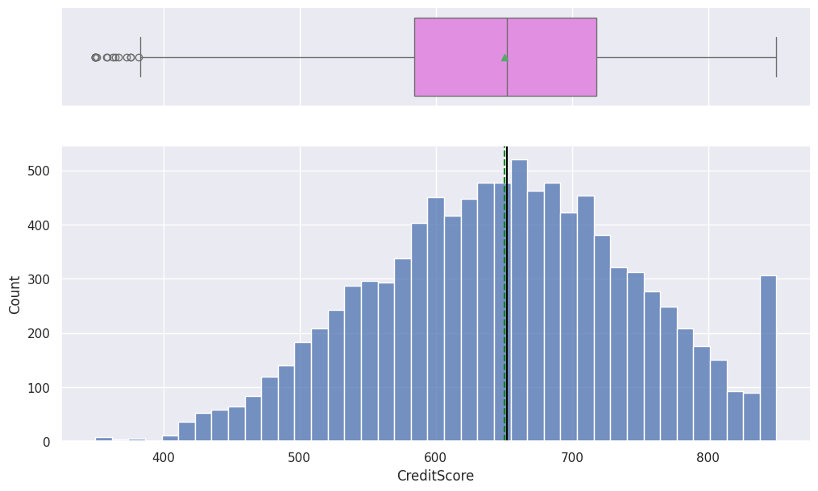

```python
# Create the Histogram and boxplot for Credit Score of customers
histogram_boxplot(bankchurn_df, 'CreditScore')
```

**Observations**

#### **Let's look at Geographical locations of the Customers**

```
Total number of Geographical locations = 3 with distinct Geographical locations ['France' 'Spain' 'Germany']
```

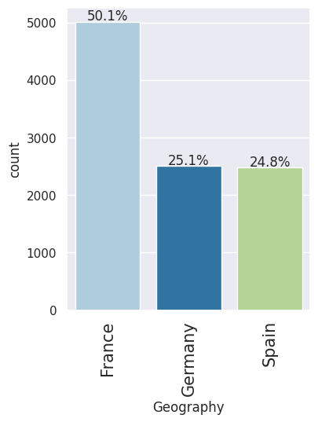

```python
# Check all unique Geographical locations exists in Geographical column
print(f"Total number of Geographical locations = {bankchurn_df['Geography'].nunique()} with distinct Geographical locations {bankchurn_df['Geography'].unique()}")

# Percentage of total Geographical locations per Geography
labeled_barplot(bankchurn_df, 'Geography', perc=True)
```

**Observations**

- There are **3 distinct location** of Geography which is France, Germany and Spain.
- The highest number of customers belongs to **France**, followed by Germany and Spain.

#### **Let's look at Gender counts of customers**

```
Gender Count = Gender
Male      5457
Female    4543
Name: count, dtype: int64
```

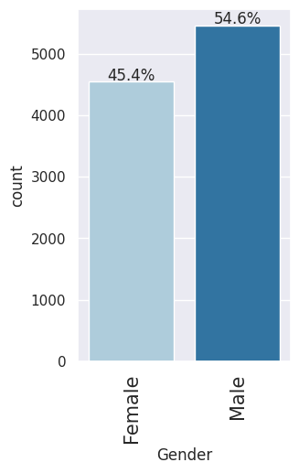

```python
# Check count per Gender type in Gender column
print(f"Gender Count = {bankchurn_df['Gender'].value_counts()}");

# Percentage of Genders among customers
labeled_barplot(bankchurn_df, 'Gender', perc=True)
```

**Observations**

- The total number of male customers is 5457, which constitutes approximately 54.6% of the customer base.
- The total number of female customers is 4543, which constitutes approximately 45.4% of the customer base.

#### **Let's look at spread of the Age of the Customers**

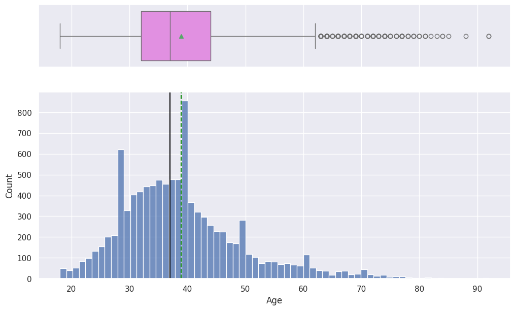

```python
# Create the Histogram and boxplot for Age of customers
histogram_boxplot(bankchurn_df, 'Age')
```

**Observations**

#### **Let's look at spread of the Tenure with the bank of the Customers**

```
Total number of Years = 11 with distinct number of Years [ 2  1  8  7  4  6  3 10  5  9  0]
```

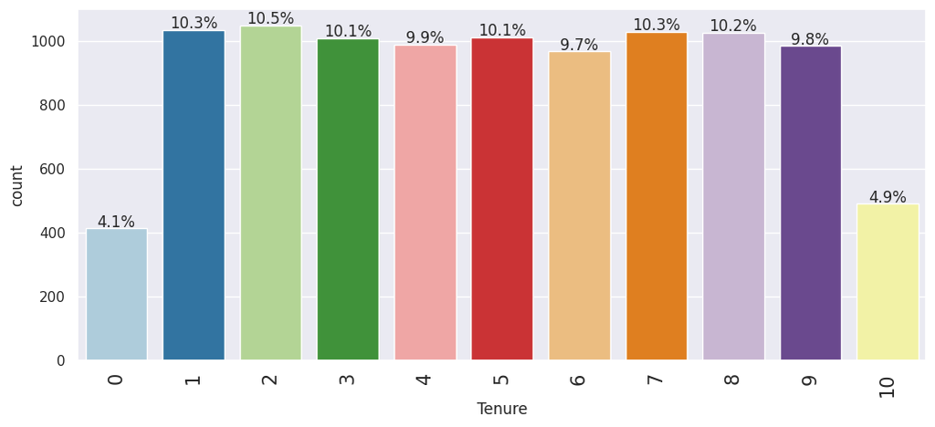

```python
# Check Tenure of customers in Years
print(f"Total number of Years = {bankchurn_df['Tenure'].nunique()} with distinct number of Years {bankchurn_df['Tenure'].unique()}")


# Percentage of products of the account holder held per number of products
labeled_barplot(bankchurn_df, 'Tenure', perc=True)
```

**Observations**

#### **Let's look at count of Total number of products held by the customer**

```
Total number of products = 4 with distinct number of products [1 3 2 4]
```

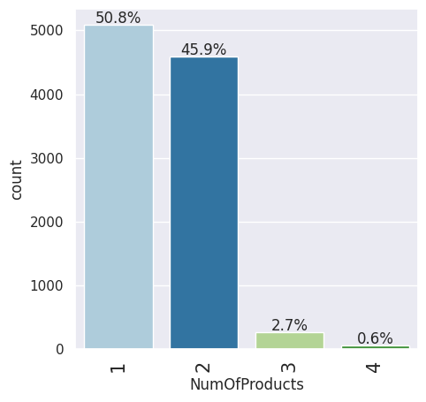

```python
# Check all number of products of the account holder
print(f"Total number of products = {bankchurn_df['NumOfProducts'].nunique()} with distinct number of products {bankchurn_df['NumOfProducts'].unique()}")


# Percentage of products of the account holder held per number of products
labeled_barplot(bankchurn_df, 'NumOfProducts', perc=True)
```

**Observations**

- The highest number of customers have **1 product**, followed by those with **2 products**.
- **2.7%** of customers use **3 products**.
- Only **.6%** of customers have **4 product**.

#### **Let's look at spread of the Balance of the Customers**

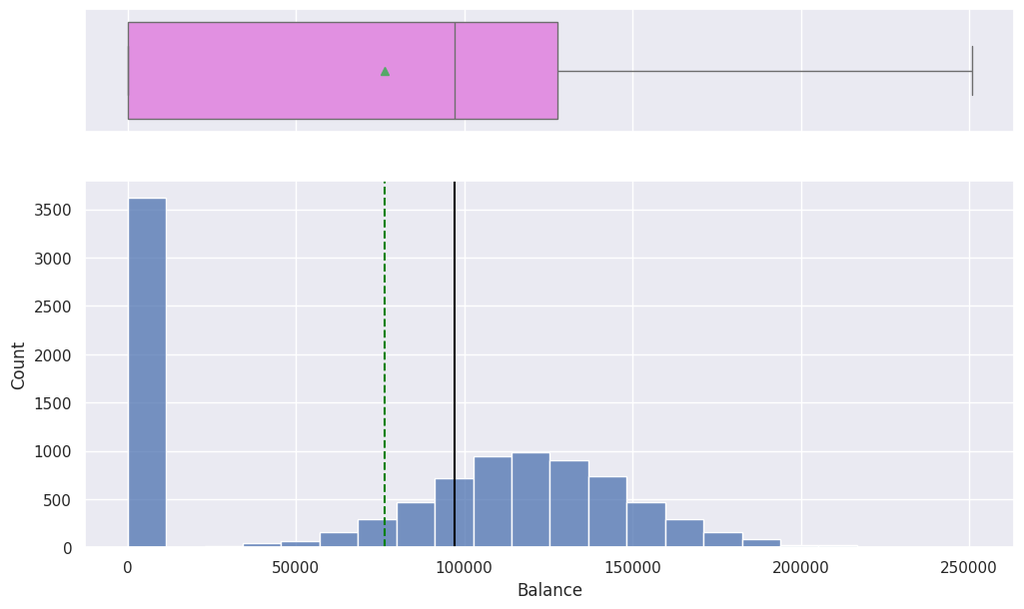

```python
# Create the Histogram and boxplot for Balance of customers
histogram_boxplot(bankchurn_df, 'Balance')
```

**Observations**

#### **Let's look at the count whether customers has Credit Card or not**

```
Customers Count = HasCrCard
1    7055
0    2945
Name: count, dtype: int64
```

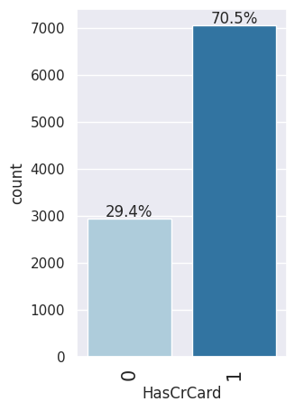

```python
# Check count of customers has Credit Card
print(f"Customers Count = {bankchurn_df['HasCrCard'].value_counts()}");

# Percentage of customers has Credit Card
labeled_barplot(bankchurn_df, 'HasCrCard', perc=True)
```

**Observations**

- The total number of customers is 7055, which constitutes approximately 70.5% of the customer base has Credit card.
- The total number of customers is 2945, which constitutes approximately 29.4% of the customer base does has Credit card.

#### **Let's look at spread of the Salary of the Customers**

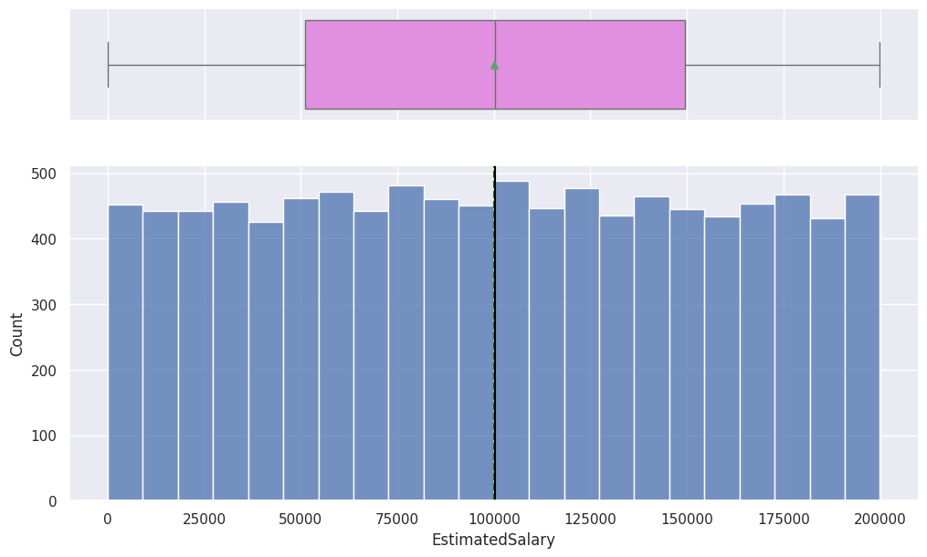

```python
# Create the Histogram and boxplot for Estimated Salary of customers
histogram_boxplot(bankchurn_df, 'EstimatedSalary')
```

**Observations**

- The Salary distribution of customers appears to be uniform.
- Most customers’ ages are earning within the range of 50k to 150k dollars.
- The mean salary is approximately 100k dollars.

#### **Let's look at the count whether the customer is an active member of the bank or not**

```
Active Customers Count = IsActiveMember
1    5151
0    4849
Name: count, dtype: int64
```

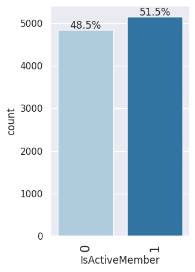

```python
# Check count of Active customers
print(f"Active Customers Count = {bankchurn_df['IsActiveMember'].value_counts()}");

# Percentage of Active customers
labeled_barplot(bankchurn_df, 'IsActiveMember', perc=True)
```

**Observations**

- The total number of customers is 5151, which constitutes approximately 51.5% of the customer base are Active members of the Bank.
- The total number of customers is 4849, which constitutes approximately 48.5% of the customer base are Non Active members of the Bank.

#### **Let's look at the count of Customer left the bank within six months**

```
Exited Count = Exited
0    7963
1    2037
Name: count, dtype: int64
```

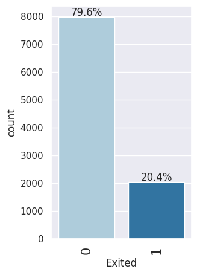

```python
# Check count of Customer left the bank vs not
print(f"Exited Count = {bankchurn_df['Exited'].value_counts()}");

# Percentage of Customers left vs not left
labeled_barplot(bankchurn_df, 'Exited', perc=True)
```

**Observations**

### Multivariate Analysis

#### **Let's look at the relationship between Customer Credit Score and Customer Exited**

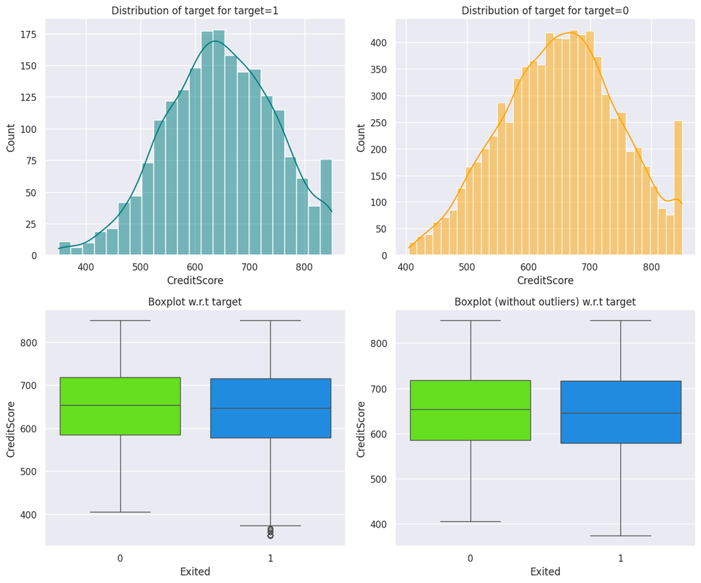

```python
# Relationship between Customer Credit Score and Customer Exited
distribution_plot_wrt_target(bankchurn_df,'CreditScore','Exited')
```

**Observationns**

- The Credit score distribution of customers follows a normal pattern for both existing and exited customers. Additionally, Credit score does not appear to significantly influence whether a customer is to Exit the bank in next 6 months

#### **Let's look at the relationship between Customer Geography and Customer Exited**

```
Exited        0     1    All
Geography
All        7963  2037  10000
Germany    1695   814   2509
France     4204   810   5014
Spain      2064   413   2477
------------------------------------------------------------------------------------------------------------------------
```

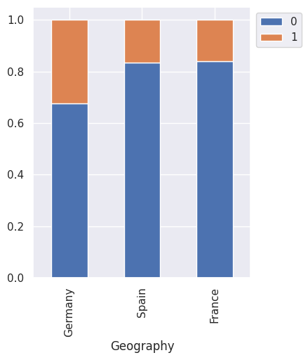

```python
# Relationship between Customer Geography and Customer Exited
stacked_barplot(bankchurn_df,'Geography','Exited')
```

**Observations**

- Customers belong to **Germany** more likely to exit the bank compare to customers belongs to Spain or France.

#### **Let's look at the relationship between Customer Gender and Customer Exited**

```
Exited     0     1    All
Gender
All     7963  2037  10000
Female  3404  1139   4543
Male    4559   898   5457
------------------------------------------------------------------------------------------------------------------------
```

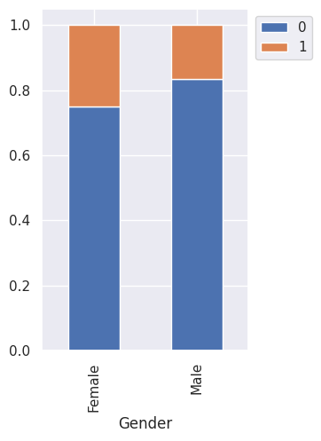

```python
# Relationship between Customer Gender and Customer Exited
stacked_barplot(bankchurn_df,'Gender','Exited')
```

**Observations**

- Female customers has high chance to leave the bank compare to Male customers.

#### **Let's look at the relationship between Customer Age and Customer Exited**

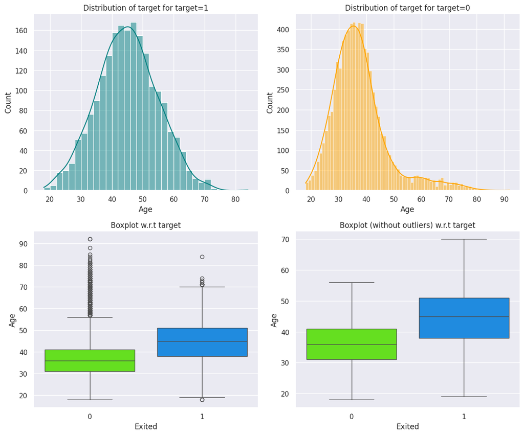

```python
# Relationship between Customer Age and Customer Exited
distribution_plot_wrt_target(bankchurn_df,'Age','Exited')
```

**Observations**

#### **Let's look at the relationship between Customer Tenure with Bank and Customer Exited**

```
Exited     0     1    All
Tenure
All     7963  2037  10000
1        803   232   1035
9        771   213    984
3        796   213   1009
5        803   209   1012
4        786   203    989
2        847   201   1048
8        828   197   1025
6        771   196    967
7        851   177   1028
10       389   101    490
0        318    95    413
------------------------------------------------------------------------------------------------------------------------
```

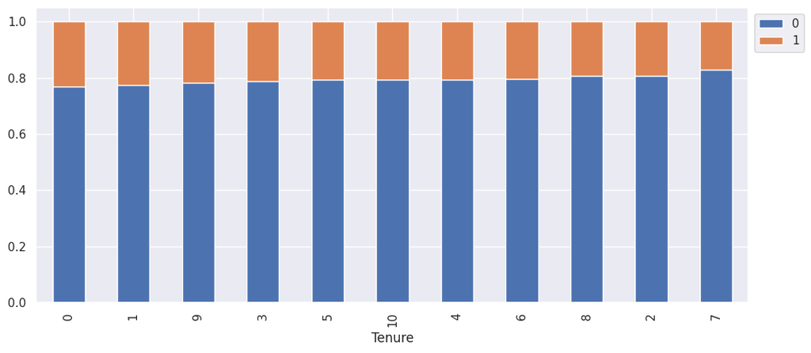

```python
# Relationship between Customer Tenure with Bank and Customer Exited
stacked_barplot(bankchurn_df,'Tenure','Exited')
```

**Observations**

#### **Let's look at the relationship between Number Of Products with Bank and Customer Exited**

```
Exited            0     1    All
NumOfProducts
All            7963  2037  10000
1              3675  1409   5084
2              4242   348   4590
3                46   220    266
4                 0    60     60
------------------------------------------------------------------------------------------------------------------------
```

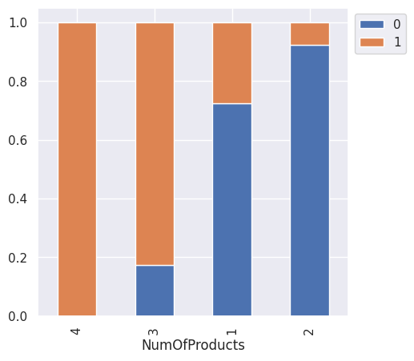

```python
# Relationship between Number Of Products with Bank and Customer Exited
stacked_barplot(bankchurn_df,'NumOfProducts','Exited')
```

**Observations**

#### **Let's look at the relationship between Customer balance and Customer Exited**

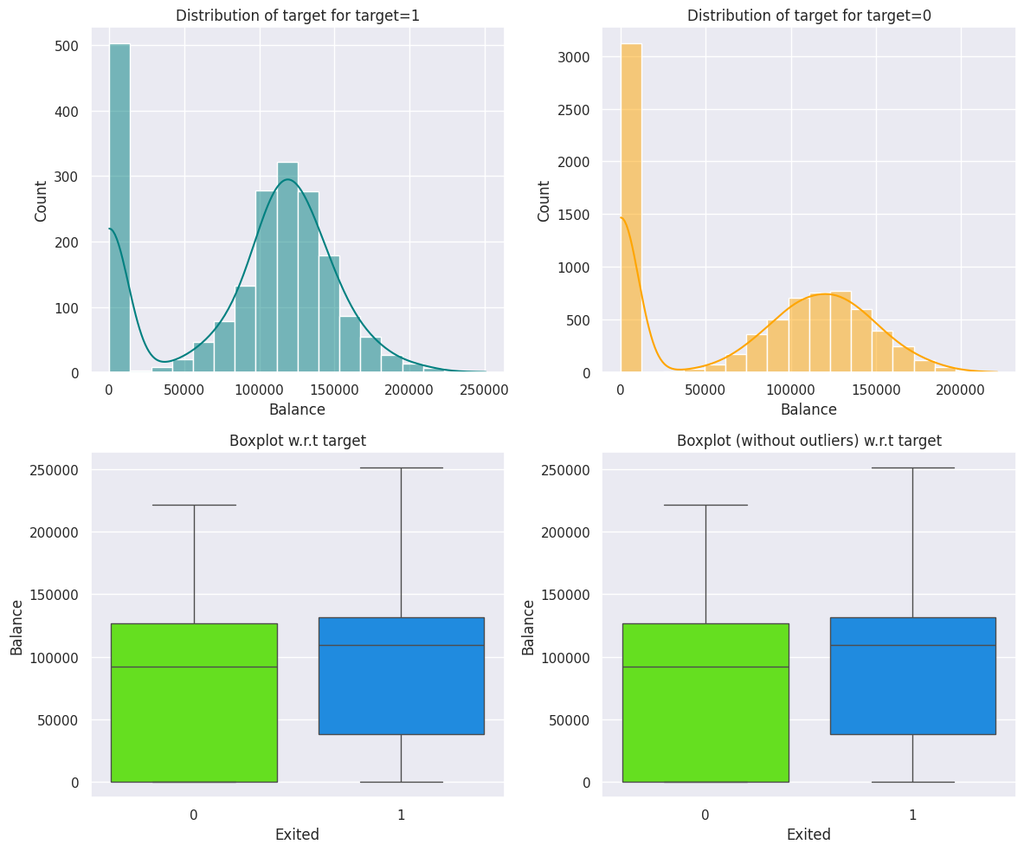

```python
# Relationship between Customer balance and Customer Exited
distribution_plot_wrt_target(bankchurn_df,'Balance','Exited')
```

#### **Let's look at the relationship between Customer has credit card or not and Customer Exited**

```
Exited        0     1    All
HasCrCard
All        7963  2037  10000
1          5631  1424   7055
0          2332   613   2945
------------------------------------------------------------------------------------------------------------------------
```

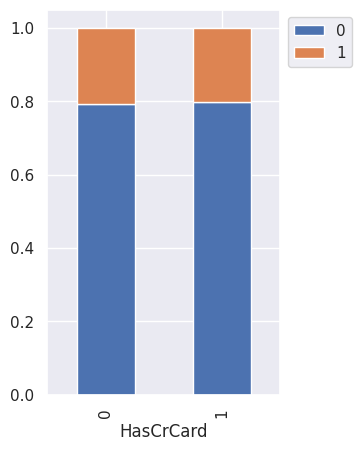

```python
# Relationship between Customer has credit card or not and Customer Exited
stacked_barplot(bankchurn_df,'HasCrCard','Exited')
```

**Observations**

- The Credit card appear to be evenly distributed among the number of customers.
- The Credit card does not seem to have a significant impact on customer attrition.

#### **Let's look at the relationship between Customer's Estimated salary and Customer Exited**

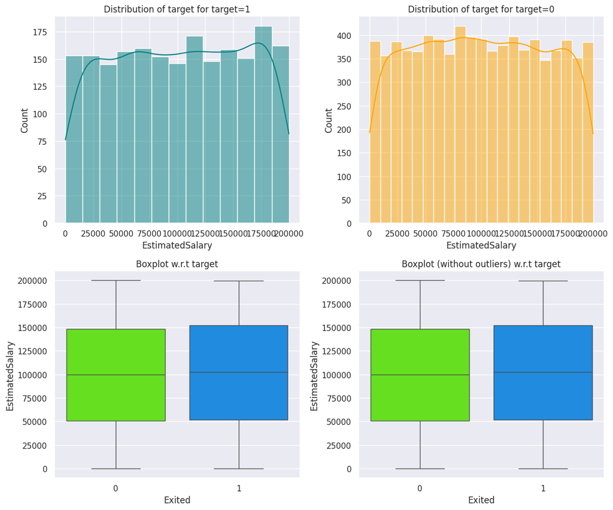

```python
# Relationship between Customer's Estimated salary and Customer Exited
distribution_plot_wrt_target(bankchurn_df,'EstimatedSalary','Exited')
```

**Observations**

#### **Let's look at the relationship between whether the customer is an active member and Customer Exited**

```
Exited             0     1    All
IsActiveMember
All             7963  2037  10000
0               3547  1302   4849
1               4416   735   5151
------------------------------------------------------------------------------------------------------------------------
```

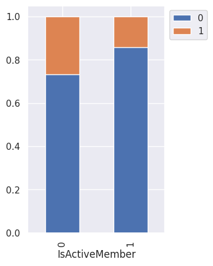

```python
# Relationship between whether the customer is an active member and Customer Exited
stacked_barplot(bankchurn_df,'IsActiveMember','Exited')
```

**Observations**

- InActive memebers is more likely to churn compare to Active customers

#### **Let's look at the co-relation between all numeric columns**

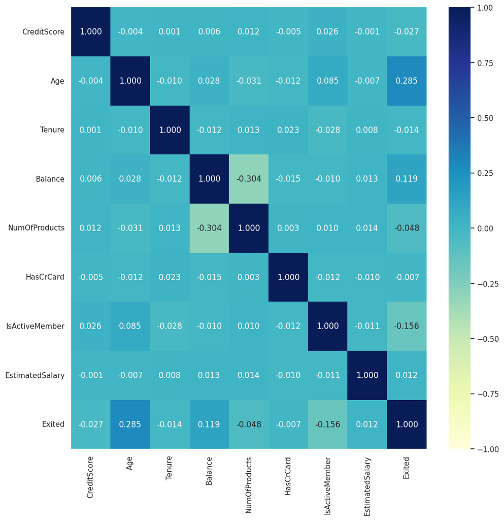

```python
# Co-relation between all numeric columns up to 3 decimals
plt.figure(figsize =(12,12))
sns.heatmap(data = bankchurn_df.select_dtypes(include=np.number).corr(),annot = True,cmap='YlGnBu',fmt=".3f",vmin=-1,vmax=1)
plt.show()
```

**Observations**

#### **Let's look at the co-relation between all numeric columns**

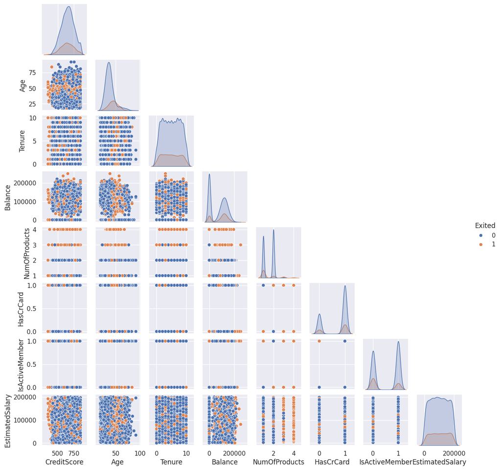

```python
# Relationship between all numeric columns
sns.pairplot(data=bankchurn_df,corner=True,hue='Exited',height = 1.5);
```

## Data Preprocessing

### Dummy Variable Creation

```python
# Encoding the categorical variables using one-hot encoding
bankchurn_df = pd.get_dummies(
    bankchurn_df,
    columns=bankchurn_df.select_dtypes(include=["object"]).columns.tolist(),
    drop_first=True,
    dtype=float
)
```

### Train-validation-test Split

```python
# Defining the explanatory (independent) and response (dependent) variables
X = bankchurn_df.drop(['Exited'],axis=1)
y = bankchurn_df['Exited']
```

```python
# Splitting the data in an 70:30 ratio for train and Test sets
X_temp, X_test, y_temp, y_test = train_test_split(X,y, test_size = 0.3, random_state = RS,stratify = y,shuffle = True)
```

```python
# Splitting the data in an 70:30 ratio for train and Validation sets
X_train, X_val, y_train, y_val = train_test_split(X_temp,y_temp, test_size = 0.3, random_state = RS,stratify = y_temp,shuffle = True)
```

```python
# Print the shape of Train, Validation and test data set along with percentage to dispay proportion distribution
print("Shape of training set:", X_train.shape, y_train.shape)
print("Shape of validation set:", X_val.shape, y_val.shape)
print("Shape of test set:", X_test.shape, y_test.shape)
print('\n')
print("Percentage of classes in training set:")
print(100*y_train.value_counts(normalize=True), '\n')
print("Percentage of classes in validation set:")
print(100*y_val.value_counts(normalize=True), '\n')
print("Percentage of classes in test set:")
print(100*y_test.value_counts(normalize=True))
```

```
Shape of training set: (4900, 11) (4900,)
Shape of validation set: (2100, 11) (2100,)
Shape of test set: (3000, 11) (3000,)


Percentage of classes in training set:
Exited
0    79.632653
1    20.367347
Name: proportion, dtype: float64

Percentage of classes in validation set:
Exited
0    79.619048
1    20.380952
Name: proportion, dtype: float64

Percentage of classes in test set:
Exited
0    79.633333
1    20.366667
Name: proportion, dtype: float64
```

```python
#Print shape of Train, Validation and Test data set
print("Shape of training set:", X_train.shape)
print("Shape of validation set:", X_val.shape)
print("Shape of test set:", X_test.shape)
```

```
Shape of training set: (4900, 11)
Shape of validation set: (2100, 11)
Shape of test set: (3000, 11)
```

### Data Normalization

```python
# defining the list of numerical columns
cat_cols_list = ["CreditScore","Age","Balance","EstimatedSalary"]
```

```python
#Standardizing the numerical variables to zero mean and unit variance.

# Creating an instance of the standard scaler
sc_transformer = StandardScaler()

X_train[cat_cols_list] = sc_transformer.fit_transform(X_train[cat_cols_list])
X_val[cat_cols_list] = sc_transformer.transform(X_val[cat_cols_list])
X_test[cat_cols_list] = sc_transformer.transform(X_test[cat_cols_list])
```

```python
#Standardizing the numerical variables for ordinal columns like Tenure and NumOfProducts

# Creating an instance of the minmaxscaler
sc_transformer = MinMaxScaler()

X_train[["Tenure","NumOfProducts"]] = sc_transformer.fit_transform(X_train[["Tenure","NumOfProducts"]])
X_val[["Tenure","NumOfProducts"]] = sc_transformer.transform(X_val[["Tenure","NumOfProducts"]])
X_test[["Tenure","NumOfProducts"]] = sc_transformer.transform(X_test[["Tenure","NumOfProducts"]])
```

```python
X_val.head()
```

|  | CreditScore | Age | Tenure | Balance | NumOfProducts | HasCrCard | IsActiveMember | EstimatedSalary | Geography_Germany | Geography_Spain | Gender_Male |
| --- | --- | --- | --- | --- | --- | --- | --- | --- | --- | --- | --- |
| 7276 | -0.588791 | -0.367958 | 0.2 | 0.914075 | 0.000000 | 1 | 1 | -0.596946 | 0.0 | 0.0 | 1.0 |
| 358 | 0.889516 | 0.204845 | 0.1 | 0.403598 | 0.000000 | 1 | 1 | 0.412785 | 0.0 | 0.0 | 1.0 |
| 7049 | -0.506089 | 0.013911 | 0.6 | 1.238489 | 0.333333 | 1 | 0 | 1.333700 | 0.0 | 0.0 | 0.0 |
| 8164 | 0.310598 | -0.081556 | 0.2 | 0.369196 | 0.333333 | 1 | 0 | -1.322851 | 0.0 | 1.0 | 1.0 |
| 5948 | -1.839666 | -0.367958 | 0.7 | 0.876484 | 0.000000 | 1 | 0 | 1.558352 | 1.0 | 0.0 | 0.0 |

### Prepared Oversampled data set for model building

```python
# Print the original Count of Labels in training set where Existing Customer = 0 and Attrited Customer = 1
print("Orginal Count of Labels \n")
print("Total counts of Exited Customer : {}".format(sum(y_train == 1)))
print("Total counts of Not Exited Customer: {} \n".format(sum(y_train == 0)))
```

```
Orginal Count of Labels

Total counts of Exited Customer : 998
Total counts of Not Exited Customer: 3902
```

```python
sm  = SMOTE(random_state=RS)
#Complete the code to fit SMOTE on the training data.
X_train_smote, y_train_smote= sm.fit_resample(X_train, y_train)
print('After UpSampling, the shape of train_X: {}'.format(X_train_smote.shape))
print('After UpSampling, the shape of train_y: {} \n'.format(y_train_smote.shape))
```

```
After UpSampling, the shape of train_X: (7804, 11)
After UpSampling, the shape of train_y: (7804,)
```

```python
# Print the Oversampled Count of Labels in training set where Existing Customer = 0 and Attrited Customer = 1
print("Oversampled Count of Labels \n")
print("Total counts of Exited Customer : {}".format(sum(y_train_smote == 1)))
print("Total counts of Not Exited Customer: {} \n".format(sum(y_train_smote == 0)))

#Print the shape of oversampled data set
print("After Oversampling\n")
print("The shape of train_X: {}".format(X_train_smote.shape))
print("The shape of train_y: {} \n".format(y_train_smote.shape))
```

```
Oversampled Count of Labels

Total counts of Exited Customer : 3902
Total counts of Not Exited Customer: 3902

After Oversampling

The shape of train_X: (7804, 11)
The shape of train_y: (7804,)
```

## Model Building

### Model Evaluation Criteria

**Model can make wrong predictions as:**

1. **False Positive/Precision:** When model predicting that a customer will Chrun but in real case the customer will not Churn - This leads to loss of resources
2. **False Negative/Recall:** When model predicting a customer will not churn but in real case the customer was going to churn - This leads to loss of opportunity

**Which case is more important?**

- For Bank case scenario losing a potential customer by predicting that the customer will not be churn but in reality the customer was going to churn.

**How to reduce this loss i.e need to reduce False Negatives or increase Recall?**

**Model Evaluation criteria**

- Bank would want **`Recall`** to be maximized, greater the Recall higher the chances of minimizing false negatives. Hence, the focus should be on increasing Recall or minimizing the false negatives.

### **Let's create a function for plotting the confusion matrix**

```python
def plot_confusion_matrix(model, predictors, target):
    """
    To plot the confusion_matrix with percentages

    model: classifier
    predictors: independent variables
    target: dependent variable
    """

    threshold=0.5

    # Predict the target values using the provided model and predictors
    y_pred = model.predict(predictors) > threshold
    #y_pred = model.predict(predictors)

    # Compute the confusion matrix comparing the true target values with the predicted values
    cm = confusion_matrix(target, y_pred)

    # Create labels for each cell in the confusion matrix with both count and percentage
    labels = np.asarray(
        [
            ["{0:0.0f}".format(item) + "\n{0:.2%}".format(item / cm.flatten().sum())]
            for item in cm.flatten()
        ]
    ).reshape(2, 2)    # reshaping to a matrix

    # Set the figure size for the plot
    plt.figure(figsize=(6, 4))

    # Plot the confusion matrix as a heatmap with the labels
    sns.heatmap(cm, annot=labels, fmt="")

    # Add a label to the y-axis
    plt.ylabel("True label")

    # Add a label to the x-axis
    plt.xlabel("Predicted label")
```

Let's create two blank dataframes that will store the recall values for all the models we build.

```python
train_metric_df = pd.DataFrame(columns=["recall"])
valid_metric_df = pd.DataFrame(columns=["recall"])
```

### **Utility functions**

```python
def plot(history, name):
    """
    Function to plot loss/accuracy

    history: an object which stores the metrics and losses.
    name: can be one of Loss or Accuracy
    """
    fig, ax = plt.subplots() #Creating a subplot with figure and axes.
    plt.plot(history.history[name]) #Plotting the train accuracy or train loss
    plt.plot(history.history['val_'+name]) #Plotting the validation accuracy or validation loss

    plt.title('Model ' + name.capitalize()) #Defining the title of the plot.
    plt.ylabel(name.capitalize()) #Capitalizing the first letter.
    plt.xlabel('Epoch') #Defining the label for the x-axis.
    fig.legend(['Train', 'Validation'], loc="outside right upper") #Defining the legend, loc controls the position of the legend.
```

```python
# defining a function to compute different metrics to check performance of a classification model built using statsmodels
def model_performance_classification(
    model, predictors, target, threshold=0.5
):
    """
    Function to compute different metrics to check classification model performance

    model: classifier
    predictors: independent variables
    target: dependent variable
    threshold: threshold for classifying the observation as class 1
    """

    # checking which probabilities are greater than threshold
    pred = model.predict(predictors) > threshold
    # pred_temp = model.predict(predictors) > threshold
    # # rounding off the above values to get classes
    # pred = np.round(pred_temp)

    acc = accuracy_score(target, pred)  # to compute Accuracy
    recall = recall_score(target, pred, average='weighted')  # to compute Recall
    precision = precision_score(target, pred, average='weighted')  # to compute Precision
    f1 = f1_score(target, pred, average='weighted')  # to compute F1-score

  # creating a dataframe of metrics
    df_perf = pd.DataFrame(
        {"Accuracy": acc, "Recall": recall, "Precision": precision, "F1 Score": f1,},
        index=[0],
    )

    return df_perf
```

### Neural Network with SGD Optimizer

First, let's set the seed for random number generators in NumPy, Python, and TensorFlow to be able to reproduce the same results everytime we run the code.

```python
# Defining the batch size and # epochs upfront as we'll be using the same values for all models
epochs = 100
batch_size = 32
```

```python
# clears the current Keras session, resetting all layers and models previously created, freeing up memory and resources.
backend.clear_session()
```

```python
# Fixing the seed for random number generators
np.random.seed(2)

random.seed(2)

tf.random.set_seed(2)
```

- Let's start with a neural network consisting of
  - One Input with 128 neurons.
  - Three hidden layers with 64, 32 and 16 neurons respectively
  - Activation function of ReLU.
  - SGD as the optimizer with learning_rate=0.001

```python
#Initializing the neural network
model_nn_with_sgd = Sequential()

# Adding the first input layer with 128 neurons and relu as activation function
model_nn_with_sgd.add(Dense(128, activation='relu', input_dim = X_train.shape[1]))

# Adding the first input layer with 64 neurons and relu as activation function
model_nn_with_sgd.add(Dense(64, activation='relu'))

# Adding the first input layer with 32 neurons and relu as activation function
model_nn_with_sgd.add(Dense(32, activation='relu'))

# Adding the second input layer with 16 neurons and relu as activation function
model_nn_with_sgd.add(Dense(16, activation='relu'))

# Adding the output input layer sigmoid as activation function
model_nn_with_sgd.add(Dense(1, activation = 'sigmoid'))
```

Let's print the summary of the model

```python
#Printing the summary.
model_nn_with_sgd.summary()
```

```
Model: "sequential"
```

```
┏━━━━━━━━━━━━━━━━━━━━━━━━━━━━━━━━━━━━━━┳━━━━━━━━━━━━━━━━━━━━━━━━━━━━━┳━━━━━━━━━━━━━━━━━┓
┃ Layer (type)                         ┃ Output Shape                ┃         Param # ┃
┡━━━━━━━━━━━━━━━━━━━━━━━━━━━━━━━━━━━━━━╇━━━━━━━━━━━━━━━━━━━━━━━━━━━━━╇━━━━━━━━━━━━━━━━━┩
│ dense (Dense)                        │ (None, 128)                 │           1,536 │
├──────────────────────────────────────┼─────────────────────────────┼─────────────────┤
│ dense_1 (Dense)                      │ (None, 64)                  │           8,256 │
├──────────────────────────────────────┼─────────────────────────────┼─────────────────┤
│ dense_2 (Dense)                      │ (None, 32)                  │           2,080 │
├──────────────────────────────────────┼─────────────────────────────┼─────────────────┤
│ dense_3 (Dense)                      │ (None, 16)                  │             528 │
├──────────────────────────────────────┼─────────────────────────────┼─────────────────┤
│ dense_4 (Dense)                      │ (None, 1)                   │              17 │
└──────────────────────────────────────┴─────────────────────────────┴─────────────────┘
```

```
 Total params: 12,417 (48.50 KB)
```

```
 Trainable params: 12,417 (48.50 KB)
```

```
 Non-trainable params: 0 (0.00 B)
```

```python
#Create an instance for SGD as the optimizer.
optimizer = tf.keras.optimizers.SGD(learning_rate=0.001)
```

```python
# Compile the model
model_nn_with_sgd.compile(loss='binary_crossentropy', optimizer=optimizer, metrics=['recall'])
```

Training [Forward pass and Backpropagation]

Training the model

```python
# Now let's train the model using the below piece of code. We will use validation set for Validation.
start = time.time()
history_nn_with_sgd = model_nn_with_sgd.fit(
    X_train, y_train,
    batch_size=batch_size,
    validation_data=(X_val,y_val),
    epochs=epochs,
    verbose=1
)
end=time.time()
```

```
154/154 ━━━━━━━━━━━━━━━━━━━━ 3s 10ms/step - loss: 0.6897 - recall: 0.2509 - val_loss: 0.6754 - val_recall: 0.0070
154/154 ━━━━━━━━━━━━━━━━━━━━ 0s 2ms/step - loss: 0.6706 - recall: 0.0059 - val_loss: 0.6577 - val_recall: 0.0000e+00
154/154 ━━━━━━━━━━━━━━━━━━━━ 1s 2ms/step - loss: 0.6528 - recall: 0.0000e+00 - val_loss: 0.6403 - val_recall: 0.0000e+00
154/154 ━━━━━━━━━━━━━━━━━━━━ 0s 3ms/step - loss: 0.6353 - recall: 0.0000e+00 - val_loss: 0.6227 - val_recall: 0.0000e+00
154/154 ━━━━━━━━━━━━━━━━━━━━ 0s 3ms/step - loss: 0.6175 - recall: 0.0000e+00 - val_loss: 0.6043 - val_recall: 0.0000e+00
154/154 ━━━━━━━━━━━━━━━━━━━━ 1s 2ms/step - loss: 0.5988 - recall: 0.0000e+00 - val_loss: 0.5856 - val_recall: 0.0000e+00
154/154 ━━━━━━━━━━━━━━━━━━━━ 0s 2ms/step - loss: 0.5800 - recall: 0.0000e+00 - val_loss: 0.5680 - val_recall: 0.0000e+00
154/154 ━━━━━━━━━━━━━━━━━━━━ 0s 3ms/step - loss: 0.5626 - recall: 0.0000e+00 - val_loss: 0.5527 - val_recall: 0.0000e+00
154/154 ━━━━━━━━━━━━━━━━━━━━ 0s 3ms/step - loss: 0.5478 - recall: 0.0000e+00 - val_loss: 0.5401 - val_recall: 0.0000e+00
154/154 ━━━━━━━━━━━━━━━━━━━━ 1s 5ms/step - loss: 0.5355 - recall: 0.0000e+00 - val_loss: 0.5297 - val_recall: 0.0000e+00
154/154 ━━━━━━━━━━━━━━━━━━━━ 1s 3ms/step - loss: 0.5255 - recall: 0.0000e+00 - val_loss: 0.5213 - val_recall: 0.0000e+00
154/154 ━━━━━━━━━━━━━━━━━━━━ 1s 3ms/step - loss: 0.5173 - recall: 0.0000e+00 - val_loss: 0.5145 - val_recall: 0.0000e+00
154/154 ━━━━━━━━━━━━━━━━━━━━ 1s 3ms/step - loss: 0.5108 - recall: 0.0000e+00 - val_loss: 0.5089 - val_recall: 0.0000e+00
154/154 ━━━━━━━━━━━━━━━━━━━━ 1s 4ms/step - loss: 0.5054 - recall: 0.0000e+00 - val_loss: 0.5045 - val_recall: 0.0000e+00
154/154 ━━━━━━━━━━━━━━━━━━━━ 1s 3ms/step - loss: 0.5011 - recall: 0.0000e+00 - val_loss: 0.5008 - val_recall: 0.0000e+00
154/154 ━━━━━━━━━━━━━━━━━━━━ 0s 2ms/step - loss: 0.4977 - recall: 0.0000e+00 - val_loss: 0.4978 - val_recall: 0.0000e+00
154/154 ━━━━━━━━━━━━━━━━━━━━ 1s 3ms/step - loss: 0.4948 - recall: 0.0000e+00 - val_loss: 0.4952 - val_recall: 0.0000e+00
154/154 ━━━━━━━━━━━━━━━━━━━━ 1s 2ms/step - loss: 0.4923 - recall: 0.0000e+00 - val_loss: 0.4930 - val_recall: 0.0000e+00
154/154 ━━━━━━━━━━━━━━━━━━━━ 0s 2ms/step - loss: 0.4902 - recall: 0.0000e+00 - val_loss: 0.4911 - val_recall: 0.0000e+00
154/154 ━━━━━━━━━━━━━━━━━━━━ 1s 2ms/step - loss: 0.4884 - recall: 0.0000e+00 - val_loss: 0.4893 - val_recall: 0.0000e+00
154/154 ━━━━━━━━━━━━━━━━━━━━ 1s 2ms/step - loss: 0.4867 - recall: 0.0000e+00 - val_loss: 0.4876 - val_recall: 0.0000e+00
154/154 ━━━━━━━━━━━━━━━━━━━━ 0s 3ms/step - loss: 0.4852 - recall: 0.0000e+00 - val_loss: 0.4861 - val_recall: 0.0000e+00
154/154 ━━━━━━━━━━━━━━━━━━━━ 0s 2ms/step - loss: 0.4837 - recall: 0.0000e+00 - val_loss: 0.4846 - val_recall: 0.0000e+00
154/154 ━━━━━━━━━━━━━━━━━━━━ 1s 3ms/step - loss: 0.4823 - recall: 0.0000e+00 - val_loss: 0.4832 - val_recall: 0.0000e+00
154/154 ━━━━━━━━━━━━━━━━━━━━ 1s 3ms/step - loss: 0.4810 - recall: 0.0000e+00 - val_loss: 0.4818 - val_recall: 0.0000e+00
154/154 ━━━━━━━━━━━━━━━━━━━━ 1s 3ms/step - loss: 0.4796 - recall: 0.0000e+00 - val_loss: 0.4803 - val_recall: 0.0000e+00
154/154 ━━━━━━━━━━━━━━━━━━━━ 0s 3ms/step - loss: 0.4783 - recall: 0.0000e+00 - val_loss: 0.4789 - val_recall: 0.0000e+00
154/154 ━━━━━━━━━━━━━━━━━━━━ 0s 2ms/step - loss: 0.4770 - recall: 0.0000e+00 - val_loss: 0.4775 - val_recall: 0.0000e+00
154/154 ━━━━━━━━━━━━━━━━━━━━ 0s 3ms/step - loss: 0.4757 - recall: 0.0000e+00 - val_loss: 0.4761 - val_recall: 0.0000e+00
154/154 ━━━━━━━━━━━━━━━━━━━━ 0s 2ms/step - loss: 0.4744 - recall: 0.0000e+00 - val_loss: 0.4747 - val_recall: 0.0000e+00
154/154 ━━━━━━━━━━━━━━━━━━━━ 1s 3ms/step - loss: 0.4732 - recall: 0.0000e+00 - val_loss: 0.4734 - val_recall: 0.0000e+00
154/154 ━━━━━━━━━━━━━━━━━━━━ 1s 2ms/step - loss: 0.4719 - recall: 0.0000e+00 - val_loss: 0.4720 - val_recall: 0.0000e+00
154/154 ━━━━━━━━━━━━━━━━━━━━ 0s 3ms/step - loss: 0.4707 - recall: 0.0000e+00 - val_loss: 0.4707 - val_recall: 0.0000e+00
154/154 ━━━━━━━━━━━━━━━━━━━━ 0s 2ms/step - loss: 0.4695 - recall: 0.0000e+00 - val_loss: 0.4694 - val_recall: 0.0000e+00
154/154 ━━━━━━━━━━━━━━━━━━━━ 0s 3ms/step - loss: 0.4684 - recall: 0.0000e+00 - val_loss: 0.4682 - val_recall: 0.0000e+00
154/154 ━━━━━━━━━━━━━━━━━━━━ 1s 3ms/step - loss: 0.4673 - recall: 0.0000e+00 - val_loss: 0.4669 - val_recall: 0.0000e+00
154/154 ━━━━━━━━━━━━━━━━━━━━ 1s 3ms/step - loss: 0.4662 - recall: 0.0000e+00 - val_loss: 0.4657 - val_recall: 0.0000e+00
154/154 ━━━━━━━━━━━━━━━━━━━━ 1s 3ms/step - loss: 0.4651 - recall: 0.0000e+00 - val_loss: 0.4646 - val_recall: 0.0000e+00
154/154 ━━━━━━━━━━━━━━━━━━━━ 1s 3ms/step - loss: 0.4641 - recall: 0.0000e+00 - val_loss: 0.4634 - val_recall: 0.0000e+00
154/154 ━━━━━━━━━━━━━━━━━━━━ 1s 4ms/step - loss: 0.4631 - recall: 0.0000e+00 - val_loss: 0.4623 - val_recall: 0.0000e+00
```

[output cut: 45 more lines]

```
154/154 ━━━━━━━━━━━━━━━━━━━━ 1s 3ms/step - loss: 0.4374 - recall: 0.0342 - val_loss: 0.4305 - val_recall: 0.0210
154/154 ━━━━━━━━━━━━━━━━━━━━ 1s 4ms/step - loss: 0.4371 - recall: 0.0397 - val_loss: 0.4301 - val_recall: 0.0234
154/154 ━━━━━━━━━━━━━━━━━━━━ 1s 3ms/step - loss: 0.4369 - recall: 0.0490 - val_loss: 0.4298 - val_recall: 0.0234
154/154 ━━━━━━━━━━━━━━━━━━━━ 1s 3ms/step - loss: 0.4366 - recall: 0.0524 - val_loss: 0.4295 - val_recall: 0.0257
154/154 ━━━━━━━━━━━━━━━━━━━━ 1s 3ms/step - loss: 0.4364 - recall: 0.0588 - val_loss: 0.4292 - val_recall: 0.0327
154/154 ━━━━━━━━━━━━━━━━━━━━ 1s 3ms/step - loss: 0.4361 - recall: 0.0712 - val_loss: 0.4289 - val_recall: 0.0327
154/154 ━━━━━━━━━━━━━━━━━━━━ 1s 3ms/step - loss: 0.4359 - recall: 0.0739 - val_loss: 0.4287 - val_recall: 0.0374
154/154 ━━━━━━━━━━━━━━━━━━━━ 1s 3ms/step - loss: 0.4357 - recall: 0.0756 - val_loss: 0.4284 - val_recall: 0.0444
154/154 ━━━━━━━━━━━━━━━━━━━━ 0s 2ms/step - loss: 0.4354 - recall: 0.0796 - val_loss: 0.4281 - val_recall: 0.0584
154/154 ━━━━━━━━━━━━━━━━━━━━ 1s 2ms/step - loss: 0.4352 - recall: 0.0859 - val_loss: 0.4278 - val_recall: 0.0701
154/154 ━━━━━━━━━━━━━━━━━━━━ 1s 2ms/step - loss: 0.4350 - recall: 0.0918 - val_loss: 0.4276 - val_recall: 0.0794
154/154 ━━━━━━━━━━━━━━━━━━━━ 1s 3ms/step - loss: 0.4347 - recall: 0.0948 - val_loss: 0.4273 - val_recall: 0.0794
154/154 ━━━━━━━━━━━━━━━━━━━━ 1s 2ms/step - loss: 0.4345 - recall: 0.1047 - val_loss: 0.4271 - val_recall: 0.0864
154/154 ━━━━━━━━━━━━━━━━━━━━ 0s 2ms/step - loss: 0.4343 - recall: 0.1108 - val_loss: 0.4268 - val_recall: 0.0888
154/154 ━━━━━━━━━━━━━━━━━━━━ 1s 2ms/step - loss: 0.4340 - recall: 0.1177 - val_loss: 0.4266 - val_recall: 0.0935
```

```python
print("Time taken in seconds ",end-start)
```

```
Time taken in seconds  56.047205209732056
```

**Let's plot Loss vs No. of Epochs**

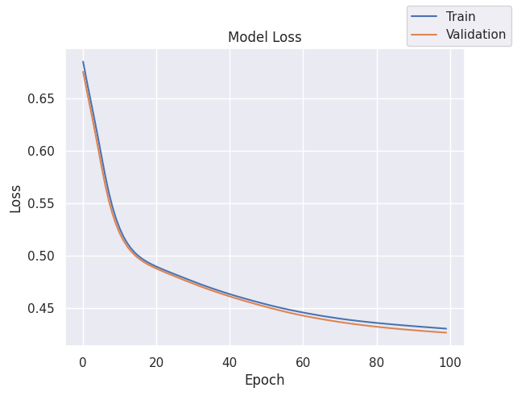

```python
plot(history_nn_with_sgd,'loss')
```

- The train and validation loss are almost the same from the 1st epoch, and a slight divergence is observed when nearing the 42th epoch.

**Let's plot Recall vs No. of Epochs**

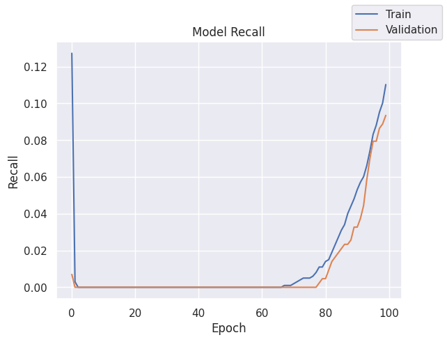

```python
plot(history_nn_with_sgd,'recall')
```

- The train and validation recall are almost the same and going hand on hand

**Let's print Training performance:**

```python
# Calculating different metrics on train set

model_sgd_train_perf = model_performance_classification(
    model_nn_with_sgd, X_train, y_train
)

print("Training performance:")
model_sgd_train_perf
```

```
154/154 ━━━━━━━━━━━━━━━━━━━━ 0s 2ms/step
Training performance:
```

|  | Accuracy | Recall | Precision | F1 Score |
| --- | --- | --- | --- | --- |
| 0 | 0.811224 | 0.811224 | 0.796297 | 0.752203 |

**Let's print Validation performance:**

```python
# Calculating different metrics on Validation set
model_sgd_val_perf = model_performance_classification(
    model_nn_with_sgd, X_val, y_val
)
print("Validation performance:")
model_sgd_val_perf
```

```
66/66 ━━━━━━━━━━━━━━━━━━━━ 0s 2ms/step
Validation performance:
```

|  | Accuracy | Recall | Precision | F1 Score |
| --- | --- | --- | --- | --- |
| 0 | 0.800952 | 0.800952 | 0.760475 | 0.739032 |

- Train Recall score of ~0.81 and validation Recall score of ~0.80 indicate consistent performance of the model between training and validation datasets while calculating using weighted average.

**Classification report**

```python
#Predicting the results using best as a threshold
y_train_pred = model_nn_with_sgd.predict(X_train)
y_train_pred = (y_train_pred > 0.5)

#Classification report on train set
cr_nn_with_sgd_train = classification_report(y_train, y_train_pred)
print(cr_nn_with_sgd_train)
```

```
154/154 ━━━━━━━━━━━━━━━━━━━━ 0s 1ms/step
              precision    recall  f1-score   support

           0       0.81      0.99      0.89      3902
           1       0.73      0.12      0.20       998

    accuracy                           0.81      4900
   macro avg       0.77      0.55      0.55      4900
weighted avg       0.80      0.81      0.75      4900
```

```python
#Predicting the results using best as a threshold
y_val_pred = model_nn_with_sgd.predict(X_val)
y_val_pred = (y_val_pred > 0.5)

#Classification report on validation set
cr_nn_with_sgd_val = classification_report(y_val, y_val_pred)
print(cr_nn_with_sgd_val)
```

```
66/66 ━━━━━━━━━━━━━━━━━━━━ 0s 1ms/step
              precision    recall  f1-score   support

           0       0.81      0.98      0.89      1672
           1       0.57      0.09      0.16       428

    accuracy                           0.80      2100
   macro avg       0.69      0.54      0.52      2100
weighted avg       0.76      0.80      0.74      2100
```

```python
model_name = "Neural Network with SGD"

train_metric_df.loc[model_name] = recall_score(y_train, y_train_pred)
valid_metric_df.loc[model_name] = recall_score(y_val, y_val_pred)
```

**Observations**

- For class 0, Train and validaiton recall is .99 and .98 respectively and well generalize
- For Class 1, Train and validaiton recall is .12 and .09 respectively and generalize
- Model seems much Bias towards Class 0 while predecting and therefore recall for class 1 is extremely less.

**Let's print the Confusion matrix**

```
154/154 ━━━━━━━━━━━━━━━━━━━━ 0s 1ms/step
```

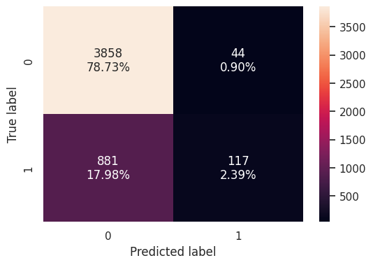

```python
# print confusion matrix on train set
plot_confusion_matrix(model_nn_with_sgd, X_train, y_train)
```

```
66/66 ━━━━━━━━━━━━━━━━━━━━ 0s 1ms/step
```

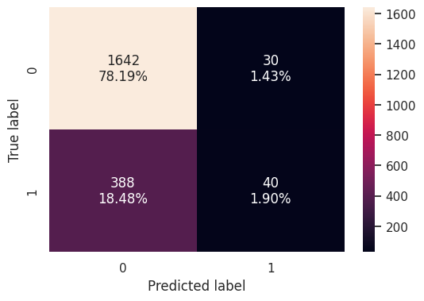

```python
# print confusion matrix on validation set
plot_confusion_matrix(model_nn_with_sgd, X_val, y_val)
```

## Model Performance Improvement

### Neural Network with Adam Optimizer

```python
# Defining the batch size and # epochs upfront as we'll be using the same values for all models
epochs = 50
batch_size = 32
```

```python
# clears the current Keras session, resetting all layers and models previously created, freeing up memory and resources.
backend.clear_session()
```

```python
# Fixing the seed for random number generators
np.random.seed(2)

random.seed(2)

tf.random.set_seed(2)
```

- Let's start with a neural network consisting of
  - One Input Layer with 32 neurons
  - Two hidden layers with 16 and 8 neurons respectively
  - Activation function of ReLU.
  - Adam as the optimizer with learning_rate=0.001

```python
#Initializing the neural network
model_nn_with_adam = Sequential()

# Adding the first input layer with 32 neurons and relu as activation function
model_nn_with_adam.add(Dense(32, activation='relu', input_dim = X_train.shape[1]))

# Adding the second input layer with 16 neurons and relu as activation function
model_nn_with_adam.add(Dense(16, activation='relu'))

# Adding the second input layer with 8 neurons and relu as activation function
model_nn_with_adam.add(Dense(8, activation='relu'))

# Adding the output input layer sigmoid as activation function
model_nn_with_adam.add(Dense(1, activation = 'sigmoid'))
```

Let's print the summary of the model

```python
#Printing the summary.
model_nn_with_adam.summary()
```

```
Model: "sequential"
```

```
┏━━━━━━━━━━━━━━━━━━━━━━━━━━━━━━━━━━━━━━┳━━━━━━━━━━━━━━━━━━━━━━━━━━━━━┳━━━━━━━━━━━━━━━━━┓
┃ Layer (type)                         ┃ Output Shape                ┃         Param # ┃
┡━━━━━━━━━━━━━━━━━━━━━━━━━━━━━━━━━━━━━━╇━━━━━━━━━━━━━━━━━━━━━━━━━━━━━╇━━━━━━━━━━━━━━━━━┩
│ dense (Dense)                        │ (None, 32)                  │             384 │
├──────────────────────────────────────┼─────────────────────────────┼─────────────────┤
│ dense_1 (Dense)                      │ (None, 16)                  │             528 │
├──────────────────────────────────────┼─────────────────────────────┼─────────────────┤
│ dense_2 (Dense)                      │ (None, 8)                   │             136 │
├──────────────────────────────────────┼─────────────────────────────┼─────────────────┤
│ dense_3 (Dense)                      │ (None, 1)                   │               9 │
└──────────────────────────────────────┴─────────────────────────────┴─────────────────┘
```

```
 Total params: 1,057 (4.13 KB)
```

```
 Trainable params: 1,057 (4.13 KB)
```

```
 Non-trainable params: 0 (0.00 B)
```

```python
#Create an instance for Adam as the optimizer.
optimizer = tf.keras.optimizers.Adam(learning_rate=0.001)
```

```python
# Compile the model
model_nn_with_adam.compile(loss='binary_crossentropy', optimizer=optimizer, metrics=['recall'])
```

Training [Forward pass and Backpropagation]

Training the model

```python
# Now let's train the model using the below piece of code. We will use validation set for Validation.
start = time.time()
history_nn_with_adam = model_nn_with_adam.fit(
    X_train, y_train,
    batch_size=batch_size,
    validation_data=(X_val,y_val),
    epochs=epochs,
    verbose=1
)
end=time.time()
```

```
154/154 ━━━━━━━━━━━━━━━━━━━━ 5s 15ms/step - loss: 0.6017 - recall: 0.2172 - val_loss: 0.4480 - val_recall: 0.0000e+00
154/154 ━━━━━━━━━━━━━━━━━━━━ 2s 3ms/step - loss: 0.4506 - recall: 0.0042 - val_loss: 0.4286 - val_recall: 0.0841
154/154 ━━━━━━━━━━━━━━━━━━━━ 0s 2ms/step - loss: 0.4399 - recall: 0.0968 - val_loss: 0.4189 - val_recall: 0.1893
154/154 ━━━━━━━━━━━━━━━━━━━━ 1s 2ms/step - loss: 0.4324 - recall: 0.1856 - val_loss: 0.4130 - val_recall: 0.2220
154/154 ━━━━━━━━━━━━━━━━━━━━ 1s 3ms/step - loss: 0.4267 - recall: 0.2157 - val_loss: 0.4092 - val_recall: 0.2687
154/154 ━━━━━━━━━━━━━━━━━━━━ 1s 3ms/step - loss: 0.4226 - recall: 0.2426 - val_loss: 0.4069 - val_recall: 0.2944
154/154 ━━━━━━━━━━━━━━━━━━━━ 1s 2ms/step - loss: 0.4186 - recall: 0.2580 - val_loss: 0.4047 - val_recall: 0.2991
154/154 ━━━━━━━━━━━━━━━━━━━━ 1s 2ms/step - loss: 0.4151 - recall: 0.2634 - val_loss: 0.4022 - val_recall: 0.3178
154/154 ━━━━━━━━━━━━━━━━━━━━ 0s 2ms/step - loss: 0.4113 - recall: 0.2779 - val_loss: 0.3997 - val_recall: 0.3224
154/154 ━━━━━━━━━━━━━━━━━━━━ 0s 3ms/step - loss: 0.4071 - recall: 0.2837 - val_loss: 0.3963 - val_recall: 0.3341
154/154 ━━━━━━━━━━━━━━━━━━━━ 1s 3ms/step - loss: 0.4022 - recall: 0.2986 - val_loss: 0.3922 - val_recall: 0.3505
154/154 ━━━━━━━━━━━━━━━━━━━━ 1s 3ms/step - loss: 0.3967 - recall: 0.3176 - val_loss: 0.3875 - val_recall: 0.3738
154/154 ━━━━━━━━━━━━━━━━━━━━ 1s 2ms/step - loss: 0.3909 - recall: 0.3347 - val_loss: 0.3819 - val_recall: 0.3808
154/154 ━━━━━━━━━━━━━━━━━━━━ 0s 3ms/step - loss: 0.3847 - recall: 0.3443 - val_loss: 0.3762 - val_recall: 0.3879
154/154 ━━━━━━━━━━━━━━━━━━━━ 0s 3ms/step - loss: 0.3777 - recall: 0.3507 - val_loss: 0.3699 - val_recall: 0.4065
154/154 ━━━━━━━━━━━━━━━━━━━━ 0s 2ms/step - loss: 0.3705 - recall: 0.3675 - val_loss: 0.3641 - val_recall: 0.4136
154/154 ━━━━━━━━━━━━━━━━━━━━ 1s 4ms/step - loss: 0.3634 - recall: 0.3712 - val_loss: 0.3592 - val_recall: 0.4276
154/154 ━━━━━━━━━━━━━━━━━━━━ 1s 4ms/step - loss: 0.3576 - recall: 0.3800 - val_loss: 0.3555 - val_recall: 0.4556
154/154 ━━━━━━━━━━━━━━━━━━━━ 1s 4ms/step - loss: 0.3531 - recall: 0.4038 - val_loss: 0.3530 - val_recall: 0.4720
154/154 ━━━━━━━━━━━━━━━━━━━━ 1s 4ms/step - loss: 0.3497 - recall: 0.4097 - val_loss: 0.3516 - val_recall: 0.4836
154/154 ━━━━━━━━━━━━━━━━━━━━ 0s 2ms/step - loss: 0.3467 - recall: 0.4234 - val_loss: 0.3509 - val_recall: 0.4907
154/154 ━━━━━━━━━━━━━━━━━━━━ 1s 3ms/step - loss: 0.3439 - recall: 0.4324 - val_loss: 0.3506 - val_recall: 0.4907
154/154 ━━━━━━━━━━━━━━━━━━━━ 1s 3ms/step - loss: 0.3420 - recall: 0.4354 - val_loss: 0.3505 - val_recall: 0.4977
154/154 ━━━━━━━━━━━━━━━━━━━━ 1s 2ms/step - loss: 0.3401 - recall: 0.4378 - val_loss: 0.3503 - val_recall: 0.5047
154/154 ━━━━━━━━━━━━━━━━━━━━ 0s 3ms/step - loss: 0.3383 - recall: 0.4400 - val_loss: 0.3502 - val_recall: 0.5000
154/154 ━━━━━━━━━━━━━━━━━━━━ 0s 3ms/step - loss: 0.3369 - recall: 0.4459 - val_loss: 0.3500 - val_recall: 0.5023
154/154 ━━━━━━━━━━━━━━━━━━━━ 1s 3ms/step - loss: 0.3354 - recall: 0.4497 - val_loss: 0.3501 - val_recall: 0.5023
154/154 ━━━━━━━━━━━━━━━━━━━━ 1s 2ms/step - loss: 0.3340 - recall: 0.4514 - val_loss: 0.3499 - val_recall: 0.5000
154/154 ━━━━━━━━━━━━━━━━━━━━ 1s 3ms/step - loss: 0.3328 - recall: 0.4576 - val_loss: 0.3502 - val_recall: 0.5070
154/154 ━━━━━━━━━━━━━━━━━━━━ 1s 2ms/step - loss: 0.3319 - recall: 0.4579 - val_loss: 0.3503 - val_recall: 0.5093
154/154 ━━━━━━━━━━━━━━━━━━━━ 1s 2ms/step - loss: 0.3308 - recall: 0.4579 - val_loss: 0.3510 - val_recall: 0.5117
154/154 ━━━━━━━━━━━━━━━━━━━━ 1s 3ms/step - loss: 0.3300 - recall: 0.4533 - val_loss: 0.3513 - val_recall: 0.5140
154/154 ━━━━━━━━━━━━━━━━━━━━ 0s 3ms/step - loss: 0.3291 - recall: 0.4715 - val_loss: 0.3514 - val_recall: 0.5117
154/154 ━━━━━━━━━━━━━━━━━━━━ 1s 3ms/step - loss: 0.3281 - recall: 0.4601 - val_loss: 0.3518 - val_recall: 0.5140
154/154 ━━━━━━━━━━━━━━━━━━━━ 0s 3ms/step - loss: 0.3273 - recall: 0.4571 - val_loss: 0.3520 - val_recall: 0.5140
154/154 ━━━━━━━━━━━━━━━━━━━━ 0s 2ms/step - loss: 0.3263 - recall: 0.4643 - val_loss: 0.3525 - val_recall: 0.5140
154/154 ━━━━━━━━━━━━━━━━━━━━ 0s 2ms/step - loss: 0.3255 - recall: 0.4617 - val_loss: 0.3531 - val_recall: 0.5140
154/154 ━━━━━━━━━━━━━━━━━━━━ 1s 3ms/step - loss: 0.3248 - recall: 0.4626 - val_loss: 0.3538 - val_recall: 0.5140
154/154 ━━━━━━━━━━━━━━━━━━━━ 1s 4ms/step - loss: 0.3241 - recall: 0.4653 - val_loss: 0.3542 - val_recall: 0.5140
154/154 ━━━━━━━━━━━━━━━━━━━━ 1s 3ms/step - loss: 0.3232 - recall: 0.4661 - val_loss: 0.3544 - val_recall: 0.5140
154/154 ━━━━━━━━━━━━━━━━━━━━ 1s 4ms/step - loss: 0.3224 - recall: 0.4714 - val_loss: 0.3548 - val_recall: 0.5140
154/154 ━━━━━━━━━━━━━━━━━━━━ 1s 4ms/step - loss: 0.3215 - recall: 0.4668 - val_loss: 0.3555 - val_recall: 0.5140
154/154 ━━━━━━━━━━━━━━━━━━━━ 1s 4ms/step - loss: 0.3207 - recall: 0.4771 - val_loss: 0.3559 - val_recall: 0.5117
154/154 ━━━━━━━━━━━━━━━━━━━━ 1s 4ms/step - loss: 0.3200 - recall: 0.4771 - val_loss: 0.3560 - val_recall: 0.5093
154/154 ━━━━━━━━━━━━━━━━━━━━ 0s 3ms/step - loss: 0.3192 - recall: 0.4771 - val_loss: 0.3566 - val_recall: 0.5140
154/154 ━━━━━━━━━━━━━━━━━━━━ 0s 3ms/step - loss: 0.3185 - recall: 0.4810 - val_loss: 0.3570 - val_recall: 0.5093
154/154 ━━━━━━━━━━━━━━━━━━━━ 0s 3ms/step - loss: 0.3178 - recall: 0.4829 - val_loss: 0.3576 - val_recall: 0.5093
154/154 ━━━━━━━━━━━━━━━━━━━━ 0s 3ms/step - loss: 0.3170 - recall: 0.4889 - val_loss: 0.3580 - val_recall: 0.5070
154/154 ━━━━━━━━━━━━━━━━━━━━ 1s 2ms/step - loss: 0.3162 - recall: 0.4896 - val_loss: 0.3586 - val_recall: 0.5117
154/154 ━━━━━━━━━━━━━━━━━━━━ 0s 2ms/step - loss: 0.3156 - recall: 0.4999 - val_loss: 0.3592 - val_recall: 0.5093
```

```python
print("Time taken in seconds ",end-start)
```

```
Time taken in seconds  34.254173278808594
```

**Let's plot Loss vs No. of Epochs**

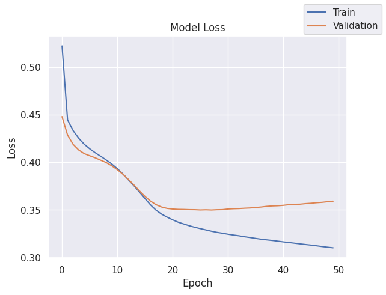

```python
plot(history_nn_with_adam,'loss')
```

- The validation loss are slowly descending till 20th epoch and then started straighten up

**Let's plot Recall vs No. of Epochs**

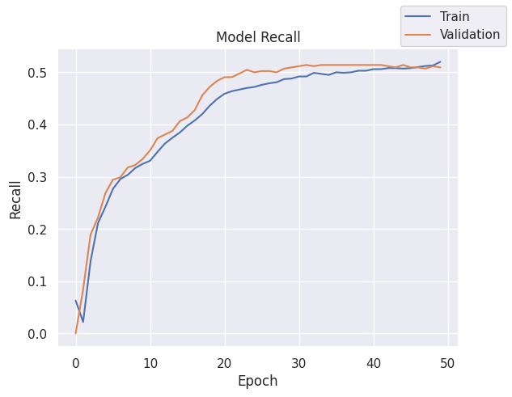

```python
plot(history_nn_with_adam,'recall')
```

- The train and validation recall are increasing at same pace till 10th epoch, and a slight divergence stars when nearing the 20th epoch.

**Let's print Training performance:**

```python
# Calculating different metrics on Training set
model_adam_train_perf = model_performance_classification(
    model_nn_with_adam, X_train, y_train
)
print("Training performance:")
model_adam_train_perf
```

```
154/154 ━━━━━━━━━━━━━━━━━━━━ 0s 2ms/step
Training performance:
```

|  | Accuracy | Recall | Precision | F1 Score |
| --- | --- | --- | --- | --- |
| 0 | 0.877755 | 0.877755 | 0.871166 | 0.869311 |

**Let's print Validation performance:**

```python
# Calculating different metrics on Validation set
model_adam_val_perf = model_performance_classification(
    model_nn_with_adam, X_val, y_val
)
print("Validation performance:")
model_adam_val_perf
```

```
66/66 ━━━━━━━━━━━━━━━━━━━━ 0s 2ms/step
Validation performance:
```

|  | Accuracy | Recall | Precision | F1 Score |
| --- | --- | --- | --- | --- |
| 0 | 0.85 | 0.85 | 0.839655 | 0.841797 |

- Train Recall score of ~0.87 and validation Recall score of ~0.85 indicate consistent performance of the model between training and validation datasets while calculating using weighted average.

**Classification Report**

```python
#Predicting the results using best as a threshold
y_train_pred = model_nn_with_adam.predict(X_train)
y_train_pred = (y_train_pred > 0.5)

#Classification report on train set
cr_nn_with_adam_train = classification_report(y_train, y_train_pred)
print(cr_nn_with_adam_train)
```

```
154/154 ━━━━━━━━━━━━━━━━━━━━ 0s 1ms/step
              precision    recall  f1-score   support

           0       0.89      0.96      0.93      3902
           1       0.78      0.55      0.65       998

    accuracy                           0.88      4900
   macro avg       0.84      0.76      0.79      4900
weighted avg       0.87      0.88      0.87      4900
```

```python
#Predicting the results using best as a threshold
y_val_pred = model_nn_with_adam.predict(X_val)
y_val_pred = (y_val_pred > 0.5)

#Classification report on validation set
cr_nn_with_adam_val = classification_report(y_val, y_val_pred)
print(cr_nn_with_adam_val)
```

```
66/66 ━━━━━━━━━━━━━━━━━━━━ 0s 1ms/step
              precision    recall  f1-score   support

           0       0.88      0.94      0.91      1672
           1       0.67      0.51      0.58       428

    accuracy                           0.85      2100
   macro avg       0.78      0.72      0.74      2100
weighted avg       0.84      0.85      0.84      2100
```

**Observations**

- For class 0, Train and validaiton recall is .96 and .94 respectively and well generalize
- For Class 1, Train and validaiton recall is .55 and .51 respectively and shows some overfitting.
- Model seems much Bias towards Class 0 while predecting and therefore recall for class 1 is very less.

```python
model_name = "Neural Network with Adam"

train_metric_df.loc[model_name] = recall_score(y_train, y_train_pred)
valid_metric_df.loc[model_name] = recall_score(y_val, y_val_pred)
```

**Let's print the Confusion matrix**

```
154/154 ━━━━━━━━━━━━━━━━━━━━ 0s 1ms/step
```

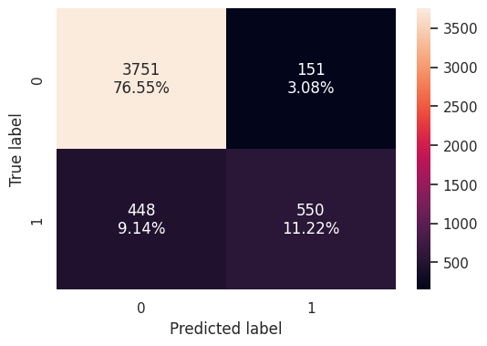

```python
# print confusion matrix on train set
plot_confusion_matrix(model_nn_with_adam, X_train, y_train)
```

```
66/66 ━━━━━━━━━━━━━━━━━━━━ 0s 1ms/step
```

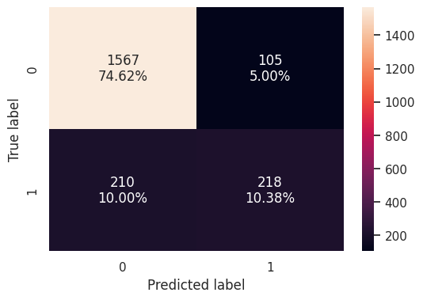

```python
# print confusion matrix on validation set
plot_confusion_matrix(model_nn_with_adam, X_val, y_val)
```

### Neural Network with Adam Optimizer and Dropout

```python
# Defining the batch size and # epochs upfront as we'll be using the same values for all models
epochs = 50
batch_size = 32
```

```python
# clears the current Keras session, resetting all layers and models previously created, freeing up memory and resources.
backend.clear_session()
```

```python
# Fixing the seed for random number generators
np.random.seed(2)

random.seed(2)

tf.random.set_seed(2)
```

- Let's start with a neural network consisting of
  - One Input layer wirh 32 neurons
  - Three layers with 16, 8 and 4 neurons respectively
  - Activation function of ReLU.
  - Two dropout with ratio of 0.2 and 01 respectively
  - Adam as the optimizer with learning_rate=0.001

```python
#Initializing the neural network
model_nn_with_adam_drop = Sequential()

# Adding the first input layer with 32 neurons and relu as activation function
model_nn_with_adam_drop.add(Dense(32, activation='relu', input_dim = X_train.shape[1]))

# Adding the first dropout with ratio of 0.2
model_nn_with_adam_drop.add(Dropout(0.2))

# Adding the second input layer with 16 neurons and relu as activation function
model_nn_with_adam_drop.add(Dense(16, activation='relu'))

# Adding the third input layer with 8 neurons and relu as activation function
model_nn_with_adam_drop.add(Dense(8, activation='relu'))

# Adding the second dropout with ratio of 0.1
model_nn_with_adam_drop.add(Dropout(0.1))

# Adding the fourth input layer with 4 neurons and relu as activation function
model_nn_with_adam_drop.add(Dense(4, activation='relu'))

# Adding the output input layer sigmoid as activation function
model_nn_with_adam_drop.add(Dense(1, activation = 'sigmoid'))
```

Let's print the summary of the model

```python
#Printing the summary.
model_nn_with_adam_drop.summary()
```

```
Model: "sequential"
```

```
┏━━━━━━━━━━━━━━━━━━━━━━━━━━━━━━━━━━━━━━┳━━━━━━━━━━━━━━━━━━━━━━━━━━━━━┳━━━━━━━━━━━━━━━━━┓
┃ Layer (type)                         ┃ Output Shape                ┃         Param # ┃
┡━━━━━━━━━━━━━━━━━━━━━━━━━━━━━━━━━━━━━━╇━━━━━━━━━━━━━━━━━━━━━━━━━━━━━╇━━━━━━━━━━━━━━━━━┩
│ dense (Dense)                        │ (None, 32)                  │             384 │
├──────────────────────────────────────┼─────────────────────────────┼─────────────────┤
│ dropout (Dropout)                    │ (None, 32)                  │               0 │
├──────────────────────────────────────┼─────────────────────────────┼─────────────────┤
│ dense_1 (Dense)                      │ (None, 16)                  │             528 │
├──────────────────────────────────────┼─────────────────────────────┼─────────────────┤
│ dense_2 (Dense)                      │ (None, 8)                   │             136 │
├──────────────────────────────────────┼─────────────────────────────┼─────────────────┤
│ dropout_1 (Dropout)                  │ (None, 8)                   │               0 │
├──────────────────────────────────────┼─────────────────────────────┼─────────────────┤
│ dense_3 (Dense)                      │ (None, 4)                   │              36 │
├──────────────────────────────────────┼─────────────────────────────┼─────────────────┤
│ dense_4 (Dense)                      │ (None, 1)                   │               5 │
└──────────────────────────────────────┴─────────────────────────────┴─────────────────┘
```

```
 Total params: 1,089 (4.25 KB)
```

```
 Trainable params: 1,089 (4.25 KB)
```

```
 Non-trainable params: 0 (0.00 B)
```

```python
#Create an instance for Adam as the optimizer.
optimizer = tf.keras.optimizers.Adam(.001)
```

```python
# Compile the model
model_nn_with_adam_drop.compile(loss='binary_crossentropy', optimizer=optimizer, metrics=['recall'])
```

```python
# Now let's train the model using the below piece of code. We will use validation set for Validation.
start = time.time()
history_nn_with_adamdrop = model_nn_with_adam_drop.fit(
    X_train, y_train,
    batch_size=batch_size,
    validation_data=(X_val,y_val),
    epochs=epochs,
    verbose=1
)
end=time.time()
```

```
154/154 ━━━━━━━━━━━━━━━━━━━━ 7s 26ms/step - loss: 0.5708 - recall: 0.0587 - val_loss: 0.4479 - val_recall: 0.0117
154/154 ━━━━━━━━━━━━━━━━━━━━ 0s 3ms/step - loss: 0.4699 - recall: 0.0181 - val_loss: 0.4336 - val_recall: 0.0794
154/154 ━━━━━━━━━━━━━━━━━━━━ 0s 3ms/step - loss: 0.4554 - recall: 0.0699 - val_loss: 0.4268 - val_recall: 0.1636
154/154 ━━━━━━━━━━━━━━━━━━━━ 1s 2ms/step - loss: 0.4463 - recall: 0.1159 - val_loss: 0.4219 - val_recall: 0.2033
154/154 ━━━━━━━━━━━━━━━━━━━━ 0s 3ms/step - loss: 0.4444 - recall: 0.1488 - val_loss: 0.4169 - val_recall: 0.2266
154/154 ━━━━━━━━━━━━━━━━━━━━ 1s 3ms/step - loss: 0.4368 - recall: 0.1551 - val_loss: 0.4120 - val_recall: 0.2780
154/154 ━━━━━━━━━━━━━━━━━━━━ 0s 2ms/step - loss: 0.4326 - recall: 0.1984 - val_loss: 0.4078 - val_recall: 0.2757
154/154 ━━━━━━━━━━━━━━━━━━━━ 0s 3ms/step - loss: 0.4342 - recall: 0.2125 - val_loss: 0.4052 - val_recall: 0.3224
154/154 ━━━━━━━━━━━━━━━━━━━━ 0s 3ms/step - loss: 0.4316 - recall: 0.2533 - val_loss: 0.4027 - val_recall: 0.3294
154/154 ━━━━━━━━━━━━━━━━━━━━ 1s 2ms/step - loss: 0.4313 - recall: 0.2458 - val_loss: 0.4004 - val_recall: 0.3388
154/154 ━━━━━━━━━━━━━━━━━━━━ 0s 3ms/step - loss: 0.4313 - recall: 0.2249 - val_loss: 0.4001 - val_recall: 0.3879
154/154 ━━━━━━━━━━━━━━━━━━━━ 1s 3ms/step - loss: 0.4304 - recall: 0.2841 - val_loss: 0.3992 - val_recall: 0.3668
154/154 ━━━━━━━━━━━━━━━━━━━━ 1s 2ms/step - loss: 0.4247 - recall: 0.2480 - val_loss: 0.4000 - val_recall: 0.3598
154/154 ━━━━━━━━━━━━━━━━━━━━ 1s 3ms/step - loss: 0.4230 - recall: 0.2664 - val_loss: 0.3979 - val_recall: 0.3925
154/154 ━━━━━━━━━━━━━━━━━━━━ 0s 2ms/step - loss: 0.4233 - recall: 0.2669 - val_loss: 0.3974 - val_recall: 0.3808
154/154 ━━━━━━━━━━━━━━━━━━━━ 0s 3ms/step - loss: 0.4196 - recall: 0.2735 - val_loss: 0.3982 - val_recall: 0.3505
154/154 ━━━━━━━━━━━━━━━━━━━━ 1s 2ms/step - loss: 0.4212 - recall: 0.2625 - val_loss: 0.3963 - val_recall: 0.3692
154/154 ━━━━━━━━━━━━━━━━━━━━ 0s 3ms/step - loss: 0.4173 - recall: 0.2752 - val_loss: 0.3961 - val_recall: 0.3949
154/154 ━━━━━━━━━━━━━━━━━━━━ 0s 2ms/step - loss: 0.4170 - recall: 0.3082 - val_loss: 0.3961 - val_recall: 0.4042
154/154 ━━━━━━━━━━━━━━━━━━━━ 1s 3ms/step - loss: 0.4183 - recall: 0.2988 - val_loss: 0.3943 - val_recall: 0.4136
154/154 ━━━━━━━━━━━━━━━━━━━━ 1s 4ms/step - loss: 0.4201 - recall: 0.2769 - val_loss: 0.3938 - val_recall: 0.4065
154/154 ━━━━━━━━━━━━━━━━━━━━ 1s 4ms/step - loss: 0.4179 - recall: 0.3068 - val_loss: 0.3944 - val_recall: 0.4393
154/154 ━━━━━━━━━━━━━━━━━━━━ 1s 4ms/step - loss: 0.4129 - recall: 0.3103 - val_loss: 0.3946 - val_recall: 0.4229
154/154 ━━━━━━━━━━━━━━━━━━━━ 1s 4ms/step - loss: 0.4136 - recall: 0.3197 - val_loss: 0.3932 - val_recall: 0.4159
154/154 ━━━━━━━━━━━━━━━━━━━━ 1s 4ms/step - loss: 0.4091 - recall: 0.3021 - val_loss: 0.3926 - val_recall: 0.4322
154/154 ━━━━━━━━━━━━━━━━━━━━ 1s 5ms/step - loss: 0.4029 - recall: 0.3030 - val_loss: 0.3918 - val_recall: 0.4112
154/154 ━━━━━━━━━━━━━━━━━━━━ 0s 3ms/step - loss: 0.4131 - recall: 0.2942 - val_loss: 0.3903 - val_recall: 0.3995
154/154 ━━━━━━━━━━━━━━━━━━━━ 0s 2ms/step - loss: 0.4050 - recall: 0.3002 - val_loss: 0.3895 - val_recall: 0.4159
154/154 ━━━━━━━━━━━━━━━━━━━━ 1s 2ms/step - loss: 0.4066 - recall: 0.3139 - val_loss: 0.3904 - val_recall: 0.4252
154/154 ━━━━━━━━━━━━━━━━━━━━ 0s 3ms/step - loss: 0.3983 - recall: 0.3347 - val_loss: 0.3899 - val_recall: 0.4486
154/154 ━━━━━━━━━━━━━━━━━━━━ 1s 2ms/step - loss: 0.4004 - recall: 0.3296 - val_loss: 0.3863 - val_recall: 0.4229
154/154 ━━━━━━━━━━━━━━━━━━━━ 0s 3ms/step - loss: 0.3945 - recall: 0.3489 - val_loss: 0.3845 - val_recall: 0.4276
154/154 ━━━━━━━━━━━━━━━━━━━━ 1s 3ms/step - loss: 0.3937 - recall: 0.3420 - val_loss: 0.3834 - val_recall: 0.4206
154/154 ━━━━━━━━━━━━━━━━━━━━ 0s 3ms/step - loss: 0.3876 - recall: 0.3537 - val_loss: 0.3810 - val_recall: 0.4299
154/154 ━━━━━━━━━━━━━━━━━━━━ 0s 3ms/step - loss: 0.3931 - recall: 0.3463 - val_loss: 0.3799 - val_recall: 0.4439
154/154 ━━━━━━━━━━━━━━━━━━━━ 0s 2ms/step - loss: 0.3947 - recall: 0.3733 - val_loss: 0.3789 - val_recall: 0.4369
154/154 ━━━━━━━━━━━━━━━━━━━━ 1s 3ms/step - loss: 0.3880 - recall: 0.3673 - val_loss: 0.3754 - val_recall: 0.4533
154/154 ━━━━━━━━━━━━━━━━━━━━ 1s 3ms/step - loss: 0.3831 - recall: 0.3896 - val_loss: 0.3737 - val_recall: 0.4486
154/154 ━━━━━━━━━━━━━━━━━━━━ 0s 3ms/step - loss: 0.3809 - recall: 0.3945 - val_loss: 0.3687 - val_recall: 0.4743
154/154 ━━━━━━━━━━━━━━━━━━━━ 0s 3ms/step - loss: 0.3743 - recall: 0.4029 - val_loss: 0.3673 - val_recall: 0.4626
154/154 ━━━━━━━━━━━━━━━━━━━━ 0s 3ms/step - loss: 0.3767 - recall: 0.3997 - val_loss: 0.3657 - val_recall: 0.4556
154/154 ━━━━━━━━━━━━━━━━━━━━ 0s 3ms/step - loss: 0.3720 - recall: 0.3964 - val_loss: 0.3650 - val_recall: 0.4603
154/154 ━━━━━━━━━━━━━━━━━━━━ 0s 3ms/step - loss: 0.3664 - recall: 0.3918 - val_loss: 0.3623 - val_recall: 0.4836
154/154 ━━━━━━━━━━━━━━━━━━━━ 0s 3ms/step - loss: 0.3648 - recall: 0.4273 - val_loss: 0.3588 - val_recall: 0.4603
154/154 ━━━━━━━━━━━━━━━━━━━━ 1s 3ms/step - loss: 0.3703 - recall: 0.3998 - val_loss: 0.3576 - val_recall: 0.4836
154/154 ━━━━━━━━━━━━━━━━━━━━ 1s 4ms/step - loss: 0.3641 - recall: 0.4083 - val_loss: 0.3530 - val_recall: 0.4790
154/154 ━━━━━━━━━━━━━━━━━━━━ 1s 4ms/step - loss: 0.3607 - recall: 0.4098 - val_loss: 0.3531 - val_recall: 0.4907
154/154 ━━━━━━━━━━━━━━━━━━━━ 1s 4ms/step - loss: 0.3676 - recall: 0.4143 - val_loss: 0.3506 - val_recall: 0.4766
154/154 ━━━━━━━━━━━━━━━━━━━━ 1s 4ms/step - loss: 0.3668 - recall: 0.3989 - val_loss: 0.3501 - val_recall: 0.4883
154/154 ━━━━━━━━━━━━━━━━━━━━ 1s 4ms/step - loss: 0.3631 - recall: 0.4202 - val_loss: 0.3506 - val_recall: 0.4813
```